# 08C Education Result Readiness

# Scope and interpretation boundary

This notebook organises the completed D08A education-network outputs for result-readiness review. It reads the eight validated point networks and their existing 1,000-repetition nonparametric edge-bootstrap summaries. It does not estimate or re-estimate a network, run a bootstrap, calculate centrality, run NCT, test education-group differences, or make political interpretations.

The primary accuracy interval used below is the 95% bootstrap percentile interval (`q2.5` to `q97.5`). Bootstrap intervals are used to describe estimation accuracy through their width. Whether an interval includes zero is retained as audit information only and is not used as a significance test, a second edge-selection rule, or a reporting gate. An edge retained under the frozen EBICglasso procedure may be described cautiously within its single network when its point estimate, interval and interval width are reported together. Wider intervals require greater interpretive caution. A regularised zero means only that the edge was not retained under the selected procedure.

The five widest intervals per group are listed as review priorities. Their rank is descriptive and is not a universal instability threshold.

# 1. Project paths, packages and helpers

```r
current_dir <- normalizePath(".", winslash = "/")

if (file.exists(file.path(current_dir, "ANES_dissertation.Rproj"))) {
  project_root <- current_dir
} else if (
  basename(current_dir) == "notebooks" &&
    file.exists(file.path(dirname(current_dir), "ANES_dissertation.Rproj"))
) {
  project_root <- dirname(current_dir)
} else {
  stop("Project root could not be identified.")
}

knitr::opts_knit$set(root.dir = project_root)

notebook_file <- file.path(
  project_root,
  "notebooks",
  "08C_education_result_readiness.Rmd"
)

formal_model_dir <- file.path(project_root, "outputs", "models", "formal")
formal_table_dir <- file.path(project_root, "outputs", "tables", "formal")
formal_figure_dir <- file.path(project_root, "outputs", "figures", "formal")
log_dir <- file.path(project_root, "outputs", "logs")

for (target_dir in c(formal_table_dir, formal_figure_dir, log_dir)) {
  dir.create(target_dir, recursive = TRUE, showWarnings = FALSE)
}

required_packages <- c("digest", "knitr", "rmarkdown")

package_gate <- data.frame(
  Package = required_packages,
  Installed = vapply(
    required_packages,
    requireNamespace,
    quietly = TRUE,
    FUN.VALUE = logical(1)
  ),
  Version = vapply(
    required_packages,
    function(package_name) {
      if (requireNamespace(package_name, quietly = TRUE)) {
        as.character(utils::packageVersion(package_name))
      } else {
        NA_character_
      }
    },
    FUN.VALUE = character(1)
  ),
  stringsAsFactors = FALSE
)

stopifnot(all(package_gate$Installed))

normalise_status <- function(value) {
  value <- toupper(trimws(as.character(value)))
  gsub("[^A-Z0-9]+", "_", value)
}

file_sha256 <- function(path) {
  if (!file.exists(path)) {
    return(NA_character_)
  }

  toupper(
    digest::digest(
      file = path,
      algo = "sha256",
      serialize = FALSE
    )
  )
}

safe_message <- function(value) {
  value <- as.character(value)
  value[is.na(value) | !nzchar(trimws(value))] <- "NONE"
  value
}

write.csv(
  package_gate,
  file.path(formal_table_dir, "08C_package_gate.csv"),
  row.names = FALSE
)

package_gate
```

```
##             Package Installed Version
## digest       digest      TRUE  0.6.39
## knitr         knitr      TRUE    1.51
## rmarkdown rmarkdown      TRUE    2.31
```

# 2. Governance gate

```r
registry_config <- file.path(
  project_root,
  "config",
  "decision_registry_path.txt"
)

stopifnot(file.exists(registry_config))

registry_lines <- trimws(readLines(registry_config, warn = FALSE))
registry_lines <- registry_lines[nzchar(registry_lines)]

stopifnot(
  length(registry_lines) == 1L,
  file.exists(registry_lines[[1L]])
)

registry_path <- registry_lines[[1L]]
decision_registry <- read.csv(
  registry_path,
  stringsAsFactors = FALSE,
  check.names = FALSE
)

decision_row <- function(decision_id) {
  decision_registry[
    decision_registry$decision_id == decision_id,
    ,
    drop = FALSE
  ]
}

d08a <- decision_row("D08A")
d08b <- decision_row("D08B")
d22 <- decision_row("D22")
d26 <- decision_row("D26")

decision_gate <- data.frame(
  Decision_ID = c("D08A", "D08B", "D22", "D26"),
  Check = c(
    "Descriptive education-network module is frozen and complete",
    "Formal education-group inference remains outside current scope",
    "One thousand nonparametric edge bootstraps are frozen and complete",
    "Eight education networks and edge bootstraps are complete and validated"
  ),
  Passed = c(
    nrow(d08a) == 1L &&
      normalise_status(d08a$decision_status) == "FROZEN" &&
      normalise_status(d08a$implementation_status) ==
        "COMPLETE_AND_VALIDATED",
    nrow(d08b) == 1L &&
      normalise_status(d08b$decision_status) ==
        "NOT_IN_CURRENT_SCOPE" &&
      normalise_status(d08b$implementation_status) == "NOT_APPLICABLE",
    nrow(d22) == 1L &&
      normalise_status(d22$decision_status) == "FROZEN" &&
      normalise_status(d22$implementation_status) ==
        "COMPLETE_AND_VALIDATED",
    nrow(d26) == 1L &&
      normalise_status(d26$decision_status) == "FROZEN" &&
      normalise_status(d26$implementation_status) ==
        "COMPLETE_AND_VALIDATED"
  ),
  stringsAsFactors = FALSE
)

write.csv(
  decision_gate,
  file.path(formal_table_dir, "08C_decision_gate.csv"),
  row.names = FALSE
)

decision_gate
```

```
##   Decision_ID
## 1        D08A
## 2        D08B
## 3         D22
## 4         D26
##                                                                     Check
## 1             Descriptive education-network module is frozen and complete
## 2          Formal education-group inference remains outside current scope
## 3      One thousand nonparametric edge bootstraps are frozen and complete
## 4 Eight education networks and edge bootstraps are complete and validated
##   Passed
## 1   TRUE
## 2   TRUE
## 3   TRUE
## 4   TRUE
```

```r
stopifnot(all(decision_gate$Passed))
```

# 3. Read-only source and hash gate

```r
source_paths <- c(
  point_models = file.path(
    formal_model_dir,
    "08B_education_eight_networks_gamma050.rds"
  ),
  bootstrap_models = file.path(
    formal_model_dir,
    "08B_education_eight_edge_bootstraps_1000.rds"
  ),
  point_diagnostics = file.path(
    formal_table_dir,
    "08B_education_point_network_diagnostics.csv"
  ),
  edge_weights = file.path(
    formal_table_dir,
    "08B_education_edge_weights.csv"
  ),
  bootstrap_summary = file.path(
    formal_table_dir,
    "08B_education_edge_bootstrap_summary.csv"
  ),
  bootstrap_diagnostics = file.path(
    formal_table_dir,
    "08B_education_edge_bootstrap_diagnostics.csv"
  ),
  completion_status = file.path(
    formal_table_dir,
    "08B_education_completion_status.csv"
  ),
  stage14_readiness = file.path(
    formal_table_dir,
    "08A_stage14_readiness.csv"
  )
)

expected_source_hashes <- c(
  point_models =
    "C0516E5248C907D832BF17DF8896D4F96EB7A7E12A1F4FE0EBE5C6817E05D9E9",
  bootstrap_models =
    "A1F4C09D39F1339FF5CE95A4B55A08BF8BD2781F91C0F72062BB2861C160BFED",
  point_diagnostics =
    "396DF68A713A7CF70D09A13A1420782FEEAF9C8D85E0C192516A95C67AAC9386",
  edge_weights =
    "094D1F9916196A898BB5322E68DD44FF7558513A9EB8A8016FEA49535AFD1BB7",
  bootstrap_summary =
    "3BE4F9A3F302C2B2682A922C68BDDD2F2DF41CFBDE36BB99B62EC66612959F2A",
  bootstrap_diagnostics =
    "B14718A9D4999518A2750FD13DBECD7B719F24D857C892741575B678E4CF789C",
  completion_status =
    "6A52971C7504A1AF043D1D84074215BDAEA981CFDAD91F1A544E13FD339CD2BE",
  stage14_readiness =
    "0506FC088C0439F6030785F9019899E5A38AD8AA0E1E2D09345A40CF1A460BF2"
)

source_gate <- data.frame(
  Input = names(source_paths),
  Path = normalizePath(source_paths, winslash = "/", mustWork = FALSE),
  Exists = file.exists(source_paths),
  Expected_SHA256 = unname(expected_source_hashes[names(source_paths)]),
  Observed_SHA256 = vapply(
    source_paths,
    file_sha256,
    FUN.VALUE = character(1)
  ),
  stringsAsFactors = FALSE
)

source_gate$Passed <-
  source_gate$Exists &
    source_gate$Observed_SHA256 == source_gate$Expected_SHA256

write.csv(
  source_gate,
  file.path(formal_table_dir, "08C_source_hash_gate.csv"),
  row.names = FALSE
)

source_gate
```

```
##                                       Input
## point_models                   point_models
## bootstrap_models           bootstrap_models
## point_diagnostics         point_diagnostics
## edge_weights                   edge_weights
## bootstrap_summary         bootstrap_summary
## bootstrap_diagnostics bootstrap_diagnostics
## completion_status         completion_status
## stage14_readiness         stage14_readiness
##                                                                                                                    Path
## point_models             D:/ANES_code/ANES_dissertation/outputs/models/formal/08B_education_eight_networks_gamma050.rds
## bootstrap_models      D:/ANES_code/ANES_dissertation/outputs/models/formal/08B_education_eight_edge_bootstraps_1000.rds
## point_diagnostics      D:/ANES_code/ANES_dissertation/outputs/tables/formal/08B_education_point_network_diagnostics.csv
## edge_weights                        D:/ANES_code/ANES_dissertation/outputs/tables/formal/08B_education_edge_weights.csv
## bootstrap_summary         D:/ANES_code/ANES_dissertation/outputs/tables/formal/08B_education_edge_bootstrap_summary.csv
## bootstrap_diagnostics D:/ANES_code/ANES_dissertation/outputs/tables/formal/08B_education_edge_bootstrap_diagnostics.csv
## completion_status              D:/ANES_code/ANES_dissertation/outputs/tables/formal/08B_education_completion_status.csv
## stage14_readiness                        D:/ANES_code/ANES_dissertation/outputs/tables/formal/08A_stage14_readiness.csv
##                       Exists
## point_models            TRUE
## bootstrap_models        TRUE
## point_diagnostics       TRUE
## edge_weights            TRUE
## bootstrap_summary       TRUE
## bootstrap_diagnostics   TRUE
## completion_status       TRUE
## stage14_readiness       TRUE
##                                                                        Expected_SHA256
## point_models          C0516E5248C907D832BF17DF8896D4F96EB7A7E12A1F4FE0EBE5C6817E05D9E9
## bootstrap_models      A1F4C09D39F1339FF5CE95A4B55A08BF8BD2781F91C0F72062BB2861C160BFED
## point_diagnostics     396DF68A713A7CF70D09A13A1420782FEEAF9C8D85E0C192516A95C67AAC9386
## edge_weights          094D1F9916196A898BB5322E68DD44FF7558513A9EB8A8016FEA49535AFD1BB7
## bootstrap_summary     3BE4F9A3F302C2B2682A922C68BDDD2F2DF41CFBDE36BB99B62EC66612959F2A
## bootstrap_diagnostics B14718A9D4999518A2750FD13DBECD7B719F24D857C892741575B678E4CF789C
## completion_status     6A52971C7504A1AF043D1D84074215BDAEA981CFDAD91F1A544E13FD339CD2BE
## stage14_readiness     0506FC088C0439F6030785F9019899E5A38AD8AA0E1E2D09345A40CF1A460BF2
##                                                                        Observed_SHA256
## point_models          C0516E5248C907D832BF17DF8896D4F96EB7A7E12A1F4FE0EBE5C6817E05D9E9
## bootstrap_models      A1F4C09D39F1339FF5CE95A4B55A08BF8BD2781F91C0F72062BB2861C160BFED
## point_diagnostics     396DF68A713A7CF70D09A13A1420782FEEAF9C8D85E0C192516A95C67AAC9386
## edge_weights          094D1F9916196A898BB5322E68DD44FF7558513A9EB8A8016FEA49535AFD1BB7
## bootstrap_summary     3BE4F9A3F302C2B2682A922C68BDDD2F2DF41CFBDE36BB99B62EC66612959F2A
## bootstrap_diagnostics B14718A9D4999518A2750FD13DBECD7B719F24D857C892741575B678E4CF789C
## completion_status     6A52971C7504A1AF043D1D84074215BDAEA981CFDAD91F1A544E13FD339CD2BE
## stage14_readiness     0506FC088C0439F6030785F9019899E5A38AD8AA0E1E2D09345A40CF1A460BF2
##                       Passed
## point_models            TRUE
## bootstrap_models        TRUE
## point_diagnostics       TRUE
## edge_weights            TRUE
## bootstrap_summary       TRUE
## bootstrap_diagnostics   TRUE
## completion_status       TRUE
## stage14_readiness       TRUE
```

```r
stopifnot(all(source_gate$Passed))
```

# 4. Read the completed D08A results

```r
point_models <- readRDS(source_paths[["point_models"]])
bootstrap_models <- readRDS(source_paths[["bootstrap_models"]])

point_diagnostics <- read.csv(
  source_paths[["point_diagnostics"]],
  stringsAsFactors = FALSE,
  check.names = FALSE
)

edge_weights <- read.csv(
  source_paths[["edge_weights"]],
  stringsAsFactors = FALSE,
  check.names = FALSE
)

bootstrap_summary <- read.csv(
  source_paths[["bootstrap_summary"]],
  stringsAsFactors = FALSE,
  check.names = FALSE
)

bootstrap_diagnostics <- read.csv(
  source_paths[["bootstrap_diagnostics"]],
  stringsAsFactors = FALSE,
  check.names = FALSE
)

completion_status <- read.csv(
  source_paths[["completion_status"]],
  stringsAsFactors = FALSE,
  check.names = FALSE
)

stage14_readiness <- read.csv(
  source_paths[["stage14_readiness"]],
  stringsAsFactors = FALSE,
  check.names = FALSE
)

network_vars <- c(
  "VCF0806",
  "VCF0809",
  "VCF0838",
  "VCF0839",
  "VCF0879a",
  "VCF0888",
  "VCF0890",
  "VCF0894",
  "VCF9223"
)

node_labels <- c(
  VCF0806 = "Health",
  VCF0809 = "Jobs",
  VCF0838 = "Abortion",
  VCF0839 = "Services",
  VCF0879a = "Immig. level",
  VCF0888 = "Crime spend",
  VCF0890 = "School spend",
  VCF0894 = "Welfare",
  VCF9223 = "Immig. jobs"
)

expected_groups <- data.frame(
  Group_key = c(
    "2012__no_college_degree",
    "2012__college_or_advanced",
    "2016__no_college_degree",
    "2016__college_or_advanced",
    "2020__no_college_degree",
    "2020__college_or_advanced",
    "2024__no_college_degree",
    "2024__college_or_advanced"
  ),
  Wave = c(2012L, 2012L, 2016L, 2016L, 2020L, 2020L, 2024L, 2024L),
  Education_group = rep(
    c("No college degree", "College or advanced degree"),
    times = 4L
  ),
  Expected_N = c(2773L, 1531L, 1478L, 1216L, 2624L, 2691L, 1729L, 1781L),
  stringsAsFactors = FALSE
)
```

# 5. Structural validation and prohibited-call audit

```r
required_bootstrap_columns <- c(
  "type", "id", "node1", "node2", "sample", "mean", "sd",
  "CIlower", "CIupper", "q2.5", "q97.5", "prop0",
  "Group_key", "Wave", "Education_group"
)

point_graphs <- lapply(
  point_models,
  function(value) value$object$graph
)

point_graph_valid <- vapply(
  point_graphs,
  function(graph) {
    is.matrix(graph) &&
      identical(dim(graph), c(9L, 9L)) &&
      identical(rownames(graph), network_vars) &&
      identical(colnames(graph), network_vars) &&
      all(is.finite(graph)) &&
      max(abs(graph - t(graph))) < 1e-12 &&
      max(abs(diag(graph))) < 1e-12
  },
  FUN.VALUE = logical(1)
)

bootstrap_counts <- vapply(
  bootstrap_models,
  function(value) length(value$object$boots),
  FUN.VALUE = integer(1)
)

bootstrap_graph_valid <- vapply(
  bootstrap_models,
  function(value) {
    all(vapply(
      value$object$boots,
      function(boot_value) {
        graph <- boot_value$graph
        is.matrix(graph) &&
          identical(dim(graph), c(9L, 9L)) &&
          all(is.finite(graph)) &&
          max(abs(graph - t(graph))) < 1e-12 &&
          max(abs(diag(graph))) < 1e-12
      },
      FUN.VALUE = logical(1)
    ))
  },
  FUN.VALUE = logical(1)
)

structural_validation <- data.frame(
  Check = c(
    "Eight point-model group keys are exact and ordered",
    "Eight bootstrap-model group keys are exact and ordered",
    "Point diagnostics contain eight ordered groups",
    "Edge-weight table contains 8 x 36 rows",
    "Bootstrap summary contains 8 x 36 rows",
    "Bootstrap diagnostics contain eight ordered groups",
    "Stage-14 readiness contains eight ordered groups",
    "Bootstrap summary contains required columns",
    "Every point graph is a valid frozen 9 x 9 graph",
    "Every stored bootstrap object contains 1,000 graphs",
    "Every stored bootstrap graph is structurally valid",
    "Every bootstrap diagnostic reports 1,000 returned networks",
    "Every bootstrap diagnostic passed validation",
    "Every Stage-14 input was ready with sparse-cell status recorded",
    "All required 08B completion rows passed"
  ),
  Passed = c(
    identical(names(point_models), expected_groups$Group_key),
    identical(names(bootstrap_models), expected_groups$Group_key),
    identical(point_diagnostics$Group_key, expected_groups$Group_key),
    nrow(edge_weights) == 288L,
    nrow(bootstrap_summary) == 288L,
    identical(bootstrap_diagnostics$Group_key, expected_groups$Group_key),
    identical(stage14_readiness$Group_key, expected_groups$Group_key),
    all(required_bootstrap_columns %in% names(bootstrap_summary)),
    all(point_graph_valid),
    identical(unname(bootstrap_counts), rep(1000L, 8L)),
    all(bootstrap_graph_valid),
    all(bootstrap_diagnostics$Returned_bootstraps == 1000L),
    all(bootstrap_diagnostics$All_validation_checks_passed),
    all(stage14_readiness$Ready_for_stage14) &&
      all(grepl("SPARSE_CELL_WARNING", stage14_readiness$Sparse_cell_status)),
    all(
      completion_status$Passed[
        completion_status$Required_for_D08A
      ]
    )
  ),
  stringsAsFactors = FALSE
)

write.csv(
  structural_validation,
  file.path(formal_table_dir, "08C_input_validation.csv"),
  row.names = FALSE
)

structural_validation
```

```
##                                                              Check Passed
## 1               Eight point-model group keys are exact and ordered   TRUE
## 2           Eight bootstrap-model group keys are exact and ordered   TRUE
## 3                   Point diagnostics contain eight ordered groups   TRUE
## 4                           Edge-weight table contains 8 x 36 rows   TRUE
## 5                           Bootstrap summary contains 8 x 36 rows   TRUE
## 6               Bootstrap diagnostics contain eight ordered groups   TRUE
## 7                 Stage-14 readiness contains eight ordered groups   TRUE
## 8                      Bootstrap summary contains required columns   TRUE
## 9                  Every point graph is a valid frozen 9 x 9 graph   TRUE
## 10             Every stored bootstrap object contains 1,000 graphs   TRUE
## 11              Every stored bootstrap graph is structurally valid   TRUE
## 12      Every bootstrap diagnostic reports 1,000 returned networks   TRUE
## 13                    Every bootstrap diagnostic passed validation   TRUE
## 14 Every Stage-14 input was ready with sparse-cell status recorded   TRUE
## 15                         All required 08B completion rows passed   TRUE
```

```r
stopifnot(all(structural_validation$Passed))
```

```r
code_lines <- readLines(notebook_file, warn = FALSE)

prohibited_patterns <- c(
  paste0("bootnet::", "estimateNetwork("),
  paste0("qgraph::", "EBICglasso("),
  paste0("bootnet::", "bootnet("),
  paste0("NetworkComparisonTest::", "NCT("),
  paste0("bootnet::", "corStability("),
  paste0("qgraph::", "centrality_auto("),
  paste0("stats::", "t.test("),
  paste0("stats::", "wilcox.test(")
)

prohibited_call_scan <- data.frame(
  Pattern = prohibited_patterns,
  Found = vapply(
    prohibited_patterns,
    function(pattern) any(grepl(pattern, code_lines, fixed = TRUE)),
    FUN.VALUE = logical(1)
  ),
  stringsAsFactors = FALSE
)

write.csv(
  prohibited_call_scan,
  file.path(formal_table_dir, "08C_prohibited_call_scan.csv"),
  row.names = FALSE
)

prohibited_call_scan
```

```
##                                                 Pattern Found
## bootnet::estimateNetwork(     bootnet::estimateNetwork( FALSE
## qgraph::EBICglasso(                 qgraph::EBICglasso( FALSE
## bootnet::bootnet(                     bootnet::bootnet( FALSE
## NetworkComparisonTest::NCT( NetworkComparisonTest::NCT( FALSE
## bootnet::corStability(           bootnet::corStability( FALSE
## qgraph::centrality_auto(       qgraph::centrality_auto( FALSE
## stats::t.test(                           stats::t.test( FALSE
## stats::wilcox.test(                 stats::wilcox.test( FALSE
```

```r
stopifnot(!any(prohibited_call_scan$Found))
```

# 6. Build the edge-accuracy review table

```r
canonicalise_edges <- function(data, node1_name, node2_name) {
  node1 <- as.character(data[[node1_name]])
  node2 <- as.character(data[[node2_name]])
  index1 <- match(node1, network_vars)
  index2 <- match(node2, network_vars)

  if (anyNA(index1) || anyNA(index2) || any(index1 == index2)) {
    stop("An edge contains an unexpected node name or a self-loop.")
  }

  first_node <- ifelse(index1 < index2, node1, node2)
  second_node <- ifelse(index1 < index2, node2, node1)

  data$Node_1 <- first_node
  data$Node_2 <- second_node
  data$Edge_ID <- paste(first_node, second_node, sep = "--")
  data
}

point_edges <- canonicalise_edges(edge_weights, "Node_1", "Node_2")
bootstrap_edges <- canonicalise_edges(bootstrap_summary, "node1", "node2")

review_joined <- merge(
  point_edges,
  bootstrap_edges,
  by = c(
    "Group_key",
    "Wave",
    "Education_group",
    "Node_1",
    "Node_2",
    "Edge_ID"
  ),
  all = FALSE,
  sort = FALSE,
  suffixes = c("_point", "_bootstrap")
)

edge_accuracy_review <- data.frame(
  Group_key = review_joined$Group_key,
  Wave = review_joined$Wave,
  Education_group = review_joined$Education_group,
  N = review_joined$N,
  Edge_ID = review_joined$Edge_ID,
  Node_1 = review_joined$Node_1,
  Node_2 = review_joined$Node_2,
  Edge_label = paste(
    unname(node_labels[review_joined$Node_1]),
    unname(node_labels[review_joined$Node_2]),
    sep = " -- "
  ),
  Point_edge = review_joined$Edge_weight,
  Retained_under_EBICglasso =
    review_joined$Retained_under_EBICglasso,
  Bootstrap_mean = review_joined$mean,
  Bootstrap_sd = review_joined$sd,
  Reported_CI_lower_sample_plus_or_minus_2SD = review_joined$CIlower,
  Reported_CI_upper_sample_plus_or_minus_2SD = review_joined$CIupper,
  Percentile_CI_2_5 = review_joined[["q2.5"]],
  Percentile_CI_97_5 = review_joined[["q97.5"]],
  Bootstrap_zero_proportion = review_joined$prop0,
  stringsAsFactors = FALSE
)

edge_accuracy_review$Reported_CI_width <-
  edge_accuracy_review$Reported_CI_upper_sample_plus_or_minus_2SD -
    edge_accuracy_review$Reported_CI_lower_sample_plus_or_minus_2SD

edge_accuracy_review$Percentile_CI_width <-
  edge_accuracy_review$Percentile_CI_97_5 -
    edge_accuracy_review$Percentile_CI_2_5

edge_accuracy_review$Percentile_CI_includes_zero <-
  edge_accuracy_review$Percentile_CI_2_5 <= 0 &
    edge_accuracy_review$Percentile_CI_97_5 >= 0

edge_accuracy_review$Point_sign <- ifelse(
  edge_accuracy_review$Point_edge > 0,
  "POSITIVE",
  ifelse(edge_accuracy_review$Point_edge < 0, "NEGATIVE", "ZERO")
)

edge_accuracy_review$Interpretation_status <- ifelse(
  edge_accuracy_review$Retained_under_EBICglasso,
  "RETAINED_UNDER_EBICGLASSO_REPORT_ESTIMATE_AND_INTERVAL",
  "NOT_RETAINED_UNDER_REGULARISATION_DO_NOT_CALL_ABSENT"
)

edge_accuracy_review$Descriptive_use <- ifelse(
  edge_accuracy_review$Retained_under_EBICglasso,
  paste(
    "May describe direction and approximate magnitude within this",
    "single network while reporting the bootstrap interval and its width;",
    "interval inclusion of zero is audit information, not a second",
    "edge-selection or significance rule; not evidence of a",
    "between-group difference."
  ),
  paste(
    "State only that the edge was not retained under the frozen",
    "regularisation procedure; do not claim absence."
  )
)
edge_accuracy_review$Between_group_inference <-
  "NOT_PERFORMED_AND_NOT_PERMITTED_FROM_THIS_TABLE"

group_order <- setNames(
  seq_len(nrow(expected_groups)),
  expected_groups$Group_key
)

node_order <- setNames(seq_along(network_vars), network_vars)

edge_accuracy_review <- edge_accuracy_review[
  order(
    unname(group_order[edge_accuracy_review$Group_key]),
    unname(node_order[edge_accuracy_review$Node_1]),
    unname(node_order[edge_accuracy_review$Node_2])
  ),
]

row.names(edge_accuracy_review) <- NULL

edge_review_validation <- data.frame(
  Check = c(
    "Joined table contains 8 x 36 unique edges",
    "Group keys are exact",
    "Every point estimate matches the bootstrap sample estimate",
    "All accuracy quantities are finite",
    "Every percentile interval is ordered",
    "Every reported plus-or-minus-2SD interval is ordered",
    "Every bootstrap zero proportion lies in [0, 1]",
    "Interval-zero audit flag agrees with the recorded endpoints",
    "Interpretation status depends only on regularised retention"
  ),
  Passed = c(
    nrow(edge_accuracy_review) == 288L &&
      !any(
        duplicated(
          paste(
            edge_accuracy_review$Group_key,
            edge_accuracy_review$Edge_ID,
            sep = "::"
          )
        )
      ),
    setequal(
      edge_accuracy_review$Group_key,
      expected_groups$Group_key
    ),
    max(
      abs(
        review_joined$Edge_weight -
          review_joined$sample
      )
    ) < 1e-12,
    all(
      vapply(
        edge_accuracy_review[
          c(
            "Point_edge",
            "Bootstrap_mean",
            "Bootstrap_sd",
            "Reported_CI_lower_sample_plus_or_minus_2SD",
            "Reported_CI_upper_sample_plus_or_minus_2SD",
            "Percentile_CI_2_5",
            "Percentile_CI_97_5",
            "Bootstrap_zero_proportion"
          )
        ],
        function(value) all(is.finite(value)),
        FUN.VALUE = logical(1)
      )
    ),
    all(
      edge_accuracy_review$Percentile_CI_2_5 <=
        edge_accuracy_review$Percentile_CI_97_5
    ),
    all(
      edge_accuracy_review$
        Reported_CI_lower_sample_plus_or_minus_2SD <=
        edge_accuracy_review$
          Reported_CI_upper_sample_plus_or_minus_2SD
    ),
    all(
      edge_accuracy_review$Bootstrap_zero_proportion >= 0 &
        edge_accuracy_review$Bootstrap_zero_proportion <= 1
    ),
    all(
      edge_accuracy_review$Percentile_CI_includes_zero ==
        (
          edge_accuracy_review$Percentile_CI_2_5 <= 0 &
            edge_accuracy_review$Percentile_CI_97_5 >= 0
        )
    ),
    all(
      ifelse(
        edge_accuracy_review$Retained_under_EBICglasso,
        edge_accuracy_review$Interpretation_status ==
          paste0(
            "RETAINED_UNDER_EBICGLASSO_",
            "REPORT_ESTIMATE_AND_INTERVAL"
          ),
        edge_accuracy_review$Interpretation_status ==
          paste0(
            "NOT_RETAINED_UNDER_REGULARISATION_",
            "DO_NOT_CALL_ABSENT"
          )
      )
    )
  ),
  stringsAsFactors = FALSE
)

write.csv(
  edge_review_validation,
  file.path(formal_table_dir, "08C_edge_review_validation.csv"),
  row.names = FALSE
)

stopifnot(all(edge_review_validation$Passed))

edge_accuracy_review_file <- file.path(
  formal_table_dir,
  "08C_education_edge_accuracy_review.csv"
)

write.csv(
  edge_accuracy_review,
  edge_accuracy_review_file,
  row.names = FALSE,
  na = ""
)

edge_review_validation
```

```
##                                                         Check Passed
## 1                   Joined table contains 8 x 36 unique edges   TRUE
## 2                                        Group keys are exact   TRUE
## 3  Every point estimate matches the bootstrap sample estimate   TRUE
## 4                          All accuracy quantities are finite   TRUE
## 5                        Every percentile interval is ordered   TRUE
## 6        Every reported plus-or-minus-2SD interval is ordered   TRUE
## 7              Every bootstrap zero proportion lies in [0, 1]   TRUE
## 8 Interval-zero audit flag agrees with the recorded endpoints   TRUE
## 9 Interpretation status depends only on regularised retention   TRUE
```

# 7. Widest intervals and group readiness

```r
widest_intervals <- do.call(
  rbind,
  lapply(
    expected_groups$Group_key,
    function(group_key) {
      group_data <- edge_accuracy_review[
        edge_accuracy_review$Group_key == group_key,
        ,
        drop = FALSE
      ]

      group_data <- group_data[
        order(-group_data$Percentile_CI_width, group_data$Edge_ID),
        ,
        drop = FALSE
      ]

      group_data$Width_rank_within_group <- seq_len(nrow(group_data))
      head(group_data, 5L)
    }
  )
)

row.names(widest_intervals) <- NULL

widest_intervals <- widest_intervals[
  ,
  c(
    "Group_key",
    "Wave",
    "Education_group",
    "N",
    "Width_rank_within_group",
    "Edge_ID",
    "Edge_label",
    "Point_edge",
    "Retained_under_EBICglasso",
    "Percentile_CI_2_5",
    "Percentile_CI_97_5",
    "Percentile_CI_width",
    "Percentile_CI_includes_zero",
    "Bootstrap_zero_proportion",
    "Interpretation_status"
  )
]

widest_intervals_file <- file.path(
  formal_table_dir,
  "08C_education_widest_intervals.csv"
)

write.csv(
  widest_intervals,
  widest_intervals_file,
  row.names = FALSE,
  na = ""
)

result_readiness <- do.call(
  rbind,
  lapply(
    expected_groups$Group_key,
    function(group_key) {
      edge_data <- edge_accuracy_review[
        edge_accuracy_review$Group_key == group_key,
        ,
        drop = FALSE
      ]

      point_row <- point_diagnostics[
        point_diagnostics$Group_key == group_key,
        ,
        drop = FALSE
      ]

      bootstrap_row <- bootstrap_diagnostics[
        bootstrap_diagnostics$Group_key == group_key,
        ,
        drop = FALSE
      ]

      readiness_row <- stage14_readiness[
        stage14_readiness$Group_key == group_key,
        ,
        drop = FALSE
      ]

                  retained <-
        edge_data$Retained_under_EBICglasso

      retained_interval_excludes_zero_audit <-
        retained &
          !edge_data$Percentile_CI_includes_zero

      retained_interval_includes_zero_audit <-
        retained &
          edge_data$Percentile_CI_includes_zero

      unretained <- !retained

      widest_index <- which.max(edge_data$Percentile_CI_width)

      all_required_valid <-
        point_row$All_validation_checks_passed &&
          bootstrap_row$All_validation_checks_passed &&
          bootstrap_row$Returned_bootstraps == 1000L &&
          readiness_row$Ready_for_stage14

      data.frame(
        Group_key = group_key,
        Wave = point_row$Wave,
        Education_group = point_row$Education_group,
        N = point_row$N,
        Nodes = point_row$Nodes,
        Possible_edges = point_row$Possible_edges,
        Retained_edges = point_row$Retained_edges,
        Not_retained_edges = sum(unretained),
        Bootstrap_repetitions = bootstrap_row$Returned_bootstraps,
                All_edges_percentile_CI_excludes_zero_audit_only =
          sum(
            !edge_data$Percentile_CI_includes_zero
          ),
        All_edges_percentile_CI_includes_zero_audit_only =
          sum(
            edge_data$Percentile_CI_includes_zero
          ),
        Retained_edges_available_for_cautious_description =
          sum(retained),
        Retained_edges_percentile_CI_excludes_zero_audit_only =
          sum(
            retained_interval_excludes_zero_audit
          ),
        Retained_edges_percentile_CI_includes_zero_audit_only =
          sum(
            retained_interval_includes_zero_audit
          ),
        Median_percentile_CI_width = median(edge_data$Percentile_CI_width),
        Maximum_percentile_CI_width = max(edge_data$Percentile_CI_width),
        Widest_interval_edge = edge_data$Edge_ID[[widest_index]],
        Widest_interval_label = edge_data$Edge_label[[widest_index]],
        Point_warning_n = point_row$Point_warning_n,
        Point_warnings = safe_message(point_row$Point_warnings),
        Bootstrap_warning_n = bootstrap_row$Captured_warning_n,
        Bootstrap_warnings = safe_message(bootstrap_row$Captured_warnings),
        Sparse_cell_status = readiness_row$Sparse_cell_status,
        Cells_0 = readiness_row$Cells_0,
        Cells_1_4 = readiness_row$Cells_1_4,
        Pairs_with_zero = readiness_row$Pairs_with_zero,
        Pairs_with_1_4 = readiness_row$Pairs_with_1_4,
        Input_and_bootstrap_checks_passed = all_required_valid,
        Result_readiness = ifelse(
          all_required_valid,
          "READY_FOR_CAUTIOUS_WITHIN_NETWORK_DESCRIPTION_WITH_LIMITATIONS",
          "REVIEW_REQUIRED"
        ),
        Permitted_scope = paste(
          "Within-network descriptive edge patterns and precision only;",
          "no education-group significance claim."
        ),
        stringsAsFactors = FALSE
      )
    }
  )
)

row.names(result_readiness) <- NULL

result_readiness_file <- file.path(
  formal_table_dir,
  "08C_education_result_readiness.csv"
)

write.csv(
  result_readiness,
  result_readiness_file,
  row.names = FALSE,
  na = ""
)

stopifnot(
  nrow(widest_intervals) == 40L,
  nrow(result_readiness) == 8L,
  all(
    result_readiness$
      Input_and_bootstrap_checks_passed
  ),
  all(
    result_readiness$Retained_edges ==
      result_readiness$
        Retained_edges_available_for_cautious_description
  ),
  all(
    result_readiness$Retained_edges ==
      result_readiness$
        Retained_edges_percentile_CI_excludes_zero_audit_only +
      result_readiness$
        Retained_edges_percentile_CI_includes_zero_audit_only
  ),
  all(
    result_readiness$Possible_edges ==
      result_readiness$Retained_edges +
        result_readiness$Not_retained_edges
  )
)

result_readiness[
  ,
  c(
    "Group_key",
    "N",
    "Retained_edges",
    "Retained_edges_available_for_cautious_description",
    "Retained_edges_percentile_CI_includes_zero_audit_only",
    "Not_retained_edges",
    "Median_percentile_CI_width",
    "Maximum_percentile_CI_width",
    "Sparse_cell_status",
    "Result_readiness"
  )
]
```

```
##                   Group_key    N Retained_edges
## 1   2012__no_college_degree 2773             28
## 2 2012__college_or_advanced 1531             28
## 3   2016__no_college_degree 1478             28
## 4 2016__college_or_advanced 1216             31
## 5   2020__no_college_degree 2624             30
## 6 2020__college_or_advanced 2691             33
## 7   2024__no_college_degree 1729             34
## 8 2024__college_or_advanced 1781             32
##   Retained_edges_available_for_cautious_description
## 1                                                28
## 2                                                28
## 3                                                28
## 4                                                31
## 5                                                30
```

[output cut: 39 more lines]

# 8. Fixed visual specification

```r
layout_angle <- pi / 2 - (seq_along(network_vars) - 1) * 2 * pi /
  length(network_vars)

fixed_layout <- cbind(cos(layout_angle), sin(layout_angle))
rownames(fixed_layout) <- network_vars

all_point_edges <- unlist(
  lapply(point_graphs, function(graph) graph[upper.tri(graph)]),
  use.names = FALSE
)

observed_maximum_absolute_edge <- max(abs(all_point_edges), na.rm = TRUE)
network_edge_scale_maximum <- 0.50

stopifnot(observed_maximum_absolute_edge <= network_edge_scale_maximum)

global_maximum_absolute_interval <- max(
  abs(c(
    edge_accuracy_review$Percentile_CI_2_5,
    edge_accuracy_review$Percentile_CI_97_5,
    edge_accuracy_review$Point_edge
  )),
  na.rm = TRUE
)

accuracy_axis_limit <- ceiling(global_maximum_absolute_interval * 20) / 20

positive_colour <- "#0072B2"
negative_colour <- "#D55E00"
unretained_colour <- "#888888"
node_fill_colour <- "#F7F7F7"
node_border_colour <- "#222222"

edge_template_index <- which(
  upper.tri(matrix(0, nrow = 9L, ncol = 9L)),
  arr.ind = TRUE
)

edge_template <- data.frame(
  Node_1 = network_vars[edge_template_index[, "row"]],
  Node_2 = network_vars[edge_template_index[, "col"]],
  stringsAsFactors = FALSE
)

edge_template$Edge_ID <- paste(
  edge_template$Node_1,
  edge_template$Node_2,
  sep = "--"
)

edge_template$Edge_label <- paste(
  unname(node_labels[edge_template$Node_1]),
  unname(node_labels[edge_template$Node_2]),
  sep = " -- "
)

visual_specification <- data.frame(
  Element = c(
    "Node order",
    "Layout",
    "Positive edge",
    "Negative edge",
    "Network edge-width scale",
    "Accuracy x-axis",
    "Accuracy interval",
    "Figure export"
  ),
  Specification = c(
    paste(network_vars, collapse = " | "),
    "Fixed nine-node circular layout for every network",
    paste0(positive_colour, "; solid line"),
    paste0(negative_colour, "; dashed line"),
    paste0(
      "Fixed common maximum absolute edge = ",
      format(network_edge_scale_maximum, digits = 6),
      "; observed maximum = ",
      format(observed_maximum_absolute_edge, digits = 6)
    ),
    paste0(
      "Common symmetric limits = +/-",
      format(accuracy_axis_limit, digits = 6)
    ),
    "95% bootstrap percentile interval (q2.5 to q97.5)",
    "PNG, opaque white background, fixed pixel dimensions and resolution"
  ),
  stringsAsFactors = FALSE
)

write.csv(
  visual_specification,
  file.path(formal_table_dir, "08C_visual_specification.csv"),
  row.names = FALSE
)

visual_specification
```

```
##                    Element
## 1               Node order
## 2                   Layout
## 3            Positive edge
## 4            Negative edge
## 5 Network edge-width scale
## 6          Accuracy x-axis
## 7        Accuracy interval
## 8            Figure export
##                                                                              Specification
## 1 VCF0806 | VCF0809 | VCF0838 | VCF0839 | VCF0879a | VCF0888 | VCF0890 | VCF0894 | VCF9223
## 2                                        Fixed nine-node circular layout for every network
## 3                                                                      #0072B2; solid line
## 4                                                                     #D55E00; dashed line
## 5                    Fixed common maximum absolute edge = 0.5; observed maximum = 0.450879
## 6                                                        Common symmetric limits = +/-0.55
## 7                                        95% bootstrap percentile interval (q2.5 to q97.5)
## 8                      PNG, opaque white background, fixed pixel dimensions and resolution
```

# 9. Generate eight fixed-layout network figures

```r
network_figure_files <- character(nrow(expected_groups))

for (group_index in seq_len(nrow(expected_groups))) {
  group_key <- expected_groups$Group_key[[group_index]]
  group_row <- result_readiness[
    result_readiness$Group_key == group_key,
    ,
    drop = FALSE
  ]
  graph <- point_graphs[[group_key]]

  figure_file <- file.path(
    formal_figure_dir,
    paste0("08C_education_network_", group_key, ".png")
  )

  grDevices::png(
    filename = figure_file,
    width = 2400,
    height = 2400,
    res = 300,
    bg = "white"
  )

  par(mar = c(6.5, 2.5, 5.0, 2.5) + 0.1, xpd = FALSE)

  plot(
    fixed_layout,
    type = "n",
    xlim = c(-1.35, 1.35),
    ylim = c(-1.30, 1.28),
    xaxs = "i",
    yaxs = "i",
    axes = FALSE,
    xlab = "",
    ylab = "",
    asp = 1,
    main = paste(group_row$Wave, group_row$Education_group, sep = " - ")
  )

  mtext(
    paste0(
      "N = ",
      format(group_row$N, big.mark = ","),
      "; retained edges = ",
      group_row$Retained_edges,
      "/36"
    ),
    side = 3,
    line = 0.2,
    cex = 0.83,
    col = "#333333"
  )

  retained_index <- which(
    upper.tri(graph) & abs(graph) > .Machine$double.eps,
    arr.ind = TRUE
  )

  if (nrow(retained_index) > 0L) {
    for (edge_index in seq_len(nrow(retained_index))) {
      row_index <- retained_index[edge_index, "row"]
      column_index <- retained_index[edge_index, "col"]
      edge_value <- graph[row_index, column_index]
      line_width <- max(
        0.55,
        7.5 * abs(edge_value) / network_edge_scale_maximum
      )

      segments(
        x0 = fixed_layout[row_index, 1],
        y0 = fixed_layout[row_index, 2],
        x1 = fixed_layout[column_index, 1],
        y1 = fixed_layout[column_index, 2],
        col = ifelse(edge_value > 0, positive_colour, negative_colour),
        lty = ifelse(edge_value > 0, 1, 2),
        lwd = line_width
      )
    }
  }

  points(
    fixed_layout[, 1],
    fixed_layout[, 2],
    pch = 21,
    cex = 5.1,
    bg = node_fill_colour,
    col = node_border_colour,
    lwd = 1.4
  )

  text(
    fixed_layout[, 1],
    fixed_layout[, 2],
    labels = unname(node_labels[network_vars]),
    cex = 0.72,
    col = "#111111"
  )

  legend(
    "bottom",
    inset = -0.17,
    horiz = TRUE,
    legend = c("Positive conditional association", "Negative conditional association"),
    col = c(positive_colour, negative_colour),
    lty = c(1, 2),
    lwd = c(3, 3),
    bty = "n",
    cex = 0.83,
    xpd = NA
  )

  mtext(
    paste0(
      "Common layout and edge-width scale across all eight panels; ",
      "regularised zero edges are not drawn."
    ),
    side = 1,
    line = 5.0,
    cex = 0.72,
    col = "#333333"
  )

  grDevices::dev.off()

  network_figure_files[[group_index]] <- figure_file
}

stopifnot(
  length(network_figure_files) == 8L,
  all(file.exists(network_figure_files)),
  all(file.info(network_figure_files)$size > 0)
)

network_figure_files
```

```
## [1] "D:/ANES_code/ANES_dissertation/outputs/figures/formal/08C_education_network_2012__no_college_degree.png"
## [2] "D:/ANES_code/ANES_dissertation/outputs/figures/formal/08C_education_network_2012__college_or_advanced.png"
## [3] "D:/ANES_code/ANES_dissertation/outputs/figures/formal/08C_education_network_2016__no_college_degree.png"
## [4] "D:/ANES_code/ANES_dissertation/outputs/figures/formal/08C_education_network_2016__college_or_advanced.png"
## [5] "D:/ANES_code/ANES_dissertation/outputs/figures/formal/08C_education_network_2020__no_college_degree.png"
## [6] "D:/ANES_code/ANES_dissertation/outputs/figures/formal/08C_education_network_2020__college_or_advanced.png"
## [7] "D:/ANES_code/ANES_dissertation/outputs/figures/formal/08C_education_network_2024__no_college_degree.png"
## [8] "D:/ANES_code/ANES_dissertation/outputs/figures/formal/08C_education_network_2024__college_or_advanced.png"
```

# 10. Generate eight edge-accuracy figures

```r
accuracy_figure_files <- character(nrow(expected_groups))

for (group_index in seq_len(nrow(expected_groups))) {
  group_key <- expected_groups$Group_key[[group_index]]
  group_row <- result_readiness[
    result_readiness$Group_key == group_key,
    ,
    drop = FALSE
  ]
  group_data <- edge_accuracy_review[
    edge_accuracy_review$Group_key == group_key,
    ,
    drop = FALSE
  ]

  group_data <- group_data[
    match(edge_template$Edge_ID, group_data$Edge_ID),
    ,
    drop = FALSE
  ]

  stopifnot(identical(group_data$Edge_ID, edge_template$Edge_ID))

  retained_positive <-
    group_data$Retained_under_EBICglasso &
      group_data$Point_edge > 0

  retained_negative <-
    group_data$Retained_under_EBICglasso &
      group_data$Point_edge < 0

  point_colours <- rep(
    unretained_colour,
    nrow(group_data)
  )

  point_symbols <- rep(
    1L,
    nrow(group_data)
  )

  interval_line_types <- rep(
    3L,
    nrow(group_data)
  )

  point_colours[retained_positive] <-
    positive_colour

  point_symbols[retained_positive] <-
    16L

  interval_line_types[retained_positive] <-
    1L

  point_colours[retained_negative] <-
    negative_colour

  point_symbols[retained_negative] <-
    15L

  interval_line_types[retained_negative] <-
    2L

  y_position <- rev(seq_len(nrow(group_data)))

  figure_file <- file.path(
    formal_figure_dir,
    paste0("08C_education_edge_accuracy_", group_key, ".png")
  )

  grDevices::png(
    filename = figure_file,
    width = 2700,
    height = 3000,
    res = 300,
    bg = "white"
  )

  par(mar = c(12.0, 14.5, 6.0, 2.5) + 0.1, xpd = FALSE)

  plot(
    group_data$Point_edge,
    y_position,
    type = "n",
    xlim = c(-accuracy_axis_limit, accuracy_axis_limit),
    ylim = c(0.5, nrow(group_data) + 0.5),
    yaxt = "n",
    xaxs = "i",
    xlab = "Regularised partial-correlation edge weight",
    ylab = "",
    main = paste0(
      group_row$Wave,
      " - ",
      group_row$Education_group,
      "\nWithin-network edge accuracy"
    ),
    cex.main = 1.05
  )

  abline(v = 0, lty = 3, col = "#222222", lwd = 1)

  segments(
    x0 = group_data$Percentile_CI_2_5,
    y0 = y_position,
    x1 = group_data$Percentile_CI_97_5,
    y1 = y_position,
    col = point_colours,
    lty = interval_line_types,
    lwd = 1.7
  )

  points(
    group_data$Point_edge,
    y_position,
    pch = point_symbols,
    col = point_colours,
    bg = point_colours,
    cex = 0.9
  )

  axis(
    side = 2,
    at = y_position,
    labels = edge_template$Edge_label,
    las = 2,
    cex.axis = 0.62
  )

  legend(
    "bottom",
    inset = -0.19,
    ncol = 3,
    legend = c(
      "Retained positive edge",
      "Retained negative edge",
      "Not retained under regularisation"
    ),
    col = c(
      positive_colour,
      negative_colour,
      unretained_colour
    ),
    pch = c(16, 15, 1),
    lty = c(1, 2, 3),
    bty = "n",
    cex = 0.72,
    xpd = NA
  )

  mtext(
    "Points are original-sample edges; bars are 95% bootstrap percentile intervals.",
    side = 1,
    line = 9.3,
    cex = 0.68,
    col = "#333333"
  )

  mtext(
    paste(
      "Interval inclusion of zero is audit information only;",
      "it is not a reporting gate or an education-group test."
    ),
    side = 1,
    line = 10.3,
    cex = 0.68,
    col = "#333333"
  )

  grDevices::dev.off()

  accuracy_figure_files[[group_index]] <- figure_file
}

stopifnot(
  length(accuracy_figure_files) == 8L,
  all(file.exists(accuracy_figure_files)),
  all(file.info(accuracy_figure_files)$size > 0)
)

accuracy_figure_files
```

```
## [1] "D:/ANES_code/ANES_dissertation/outputs/figures/formal/08C_education_edge_accuracy_2012__no_college_degree.png"
## [2] "D:/ANES_code/ANES_dissertation/outputs/figures/formal/08C_education_edge_accuracy_2012__college_or_advanced.png"
## [3] "D:/ANES_code/ANES_dissertation/outputs/figures/formal/08C_education_edge_accuracy_2016__no_college_degree.png"
## [4] "D:/ANES_code/ANES_dissertation/outputs/figures/formal/08C_education_edge_accuracy_2016__college_or_advanced.png"
## [5] "D:/ANES_code/ANES_dissertation/outputs/figures/formal/08C_education_edge_accuracy_2020__no_college_degree.png"
## [6] "D:/ANES_code/ANES_dissertation/outputs/figures/formal/08C_education_edge_accuracy_2020__college_or_advanced.png"
## [7] "D:/ANES_code/ANES_dissertation/outputs/figures/formal/08C_education_edge_accuracy_2024__no_college_degree.png"
## [8] "D:/ANES_code/ANES_dissertation/outputs/figures/formal/08C_education_edge_accuracy_2024__college_or_advanced.png"
```

# 11. Figure manifest and final validation

```r
figure_manifest <- rbind(
  data.frame(
    Figure_type = "FIXED_LAYOUT_NETWORK",
    Group_key = expected_groups$Group_key,
    Wave = expected_groups$Wave,
    Education_group = expected_groups$Education_group,
    Path = normalizePath(
      network_figure_files,
      winslash = "/",
      mustWork = TRUE
    ),
    Width_px = 2400L,
    Height_px = 2400L,
    Resolution_ppi = 300L,
    Common_scale = paste0(
      "Maximum absolute edge = ",
      format(network_edge_scale_maximum, digits = 8),
      "; observed maximum = ",
      format(observed_maximum_absolute_edge, digits = 8)
    ),
    stringsAsFactors = FALSE
  ),
  data.frame(
    Figure_type = "EDGE_ACCURACY",
    Group_key = expected_groups$Group_key,
    Wave = expected_groups$Wave,
    Education_group = expected_groups$Education_group,
    Path = normalizePath(
      accuracy_figure_files,
      winslash = "/",
      mustWork = TRUE
    ),
    Width_px = 2700L,
    Height_px = 3000L,
    Resolution_ppi = 300L,
    Common_scale = paste0(
      "Symmetric x-axis +/-",
      format(accuracy_axis_limit, digits = 8)
    ),
    stringsAsFactors = FALSE
  )
)

figure_manifest$Bytes <- file.info(figure_manifest$Path)$size
figure_manifest$SHA256 <- vapply(
  figure_manifest$Path,
  file_sha256,
  FUN.VALUE = character(1)
)

figure_manifest_file <- file.path(
  formal_table_dir,
  "08C_education_figure_manifest.csv"
)

write.csv(
  figure_manifest,
  figure_manifest_file,
  row.names = FALSE
)

final_validation <- data.frame(
  Check = c(
    "Source hash gate passed",
    "Governance gate passed",
    "Structural input validation passed",
    "Prohibited-call audit passed",
    "Edge-review validation passed",
    "Edge-accuracy review contains 288 rows",
    "Widest-interval table contains five rows per group",
    "Result-readiness table contains eight groups",
    "Eight network figures exist and are non-empty",
    "Eight accuracy figures exist and are non-empty",
    "All figures have recorded hashes",
    "No formal between-group inference field was populated"
  ),
  Passed = c(
    all(source_gate$Passed),
    all(decision_gate$Passed),
    all(structural_validation$Passed),
    !any(prohibited_call_scan$Found),
    all(edge_review_validation$Passed),
    nrow(edge_accuracy_review) == 288L,
    nrow(widest_intervals) == 40L &&
      all(table(widest_intervals$Group_key) == 5L),
    nrow(result_readiness) == 8L,
    length(network_figure_files) == 8L &&
      all(file.info(network_figure_files)$size > 0),
    length(accuracy_figure_files) == 8L &&
      all(file.info(accuracy_figure_files)$size > 0),
    all(nzchar(figure_manifest$SHA256)),
    all(
      edge_accuracy_review$Between_group_inference ==
        "NOT_PERFORMED_AND_NOT_PERMITTED_FROM_THIS_TABLE"
    )
  ),
  stringsAsFactors = FALSE
)

write.csv(
  final_validation,
  file.path(formal_table_dir, "08C_final_validation.csv"),
  row.names = FALSE
)

final_validation
```

```
##                                                    Check Passed
## 1                                Source hash gate passed   TRUE
## 2                                 Governance gate passed   TRUE
## 3                     Structural input validation passed   TRUE
## 4                           Prohibited-call audit passed   TRUE
## 5                          Edge-review validation passed   TRUE
## 6                 Edge-accuracy review contains 288 rows   TRUE
## 7     Widest-interval table contains five rows per group   TRUE
## 8           Result-readiness table contains eight groups   TRUE
## 9          Eight network figures exist and are non-empty   TRUE
## 10        Eight accuracy figures exist and are non-empty   TRUE
## 11                      All figures have recorded hashes   TRUE
## 12 No formal between-group inference field was populated   TRUE
```

```r
stopifnot(all(final_validation$Passed))
```

# 12. Readiness summary

Education-network result readiness. The interval-width summaries describe within-network estimation accuracy. Counts based on whether an interval includes zero are retained for audit only and are not edge-selection, significance or reporting criteria. None of these quantities provides evidence that the two education groups differ.

| Wave | Education_group | N | Retained_edges | Retained_edges_available_for_cautious_description | Retained_edges_percentile_CI_includes_zero_audit_only | Not_retained_edges | Not_retained_edges.1 | Median_percentile_CI_width | Maximum_percentile_CI_width | Result_readiness |
| --- | --- | --- | --- | --- | --- | --- | --- | --- | --- | --- |
| 2012 | No college degree | 2773 | 28 | 28 | 10 | 8 | 8 | 0.089 | 0.117 | READY_FOR_CAUTIOUS_WITHIN_NETWORK_DESCRIPTION_WITH_LIMITATIONS |
| 2012 | College or advanced degree | 1531 | 28 | 28 | 8 | 8 | 8 | 0.123 | 0.172 | READY_FOR_CAUTIOUS_WITHIN_NETWORK_DESCRIPTION_WITH_LIMITATIONS |
| 2016 | No college degree | 1478 | 28 | 28 | 9 | 8 | 8 | 0.122 | 0.176 | READY_FOR_CAUTIOUS_WITHIN_NETWORK_DESCRIPTION_WITH_LIMITATIONS |
| 2016 | College or advanced degree | 1216 | 31 | 31 | 12 | 5 | 5 | 0.141 | 0.186 | READY_FOR_CAUTIOUS_WITHIN_NETWORK_DESCRIPTION_WITH_LIMITATIONS |
| 2020 | No college degree | 2624 | 30 | 30 | 9 | 6 | 6 | 0.093 | 0.130 | READY_FOR_CAUTIOUS_WITHIN_NETWORK_DESCRIPTION_WITH_LIMITATIONS |
| 2020 | College or advanced degree | 2691 | 33 | 33 | 8 | 3 | 3 | 0.103 | 0.128 | READY_FOR_CAUTIOUS_WITHIN_NETWORK_DESCRIPTION_WITH_LIMITATIONS |
| 2024 | No college degree | 1729 | 34 | 34 | 12 | 2 | 2 | 0.120 | 0.174 | READY_FOR_CAUTIOUS_WITHIN_NETWORK_DESCRIPTION_WITH_LIMITATIONS |
| 2024 | College or advanced degree | 1781 | 32 | 32 | 10 | 4 | 4 | 0.125 | 0.175 | READY_FOR_CAUTIOUS_WITHIN_NETWORK_DESCRIPTION_WITH_LIMITATIONS |

# 13. Widest intervals requiring the greatest caution

Five widest 95% bootstrap percentile intervals per group. Width rank is an audit aid, not a universal cutoff.

| Wave | Education_group | Width_rank_within_group | Edge_label | Point_edge | Percentile_CI_2_5 | Percentile_CI_97_5 | Percentile_CI_width | Interpretation_status |
| --- | --- | --- | --- | --- | --- | --- | --- | --- |
| 2012 | No college degree | 1 | School spend – Welfare | 0.148 | 0.093 | 0.211 | 0.117 | RETAINED_UNDER_EBICGLASSO_REPORT_ESTIMATE_AND_INTERVAL |
| 2012 | No college degree | 2 | Immig. level – Crime spend | -0.080 | -0.128 | -0.017 | 0.110 | RETAINED_UNDER_EBICGLASSO_REPORT_ESTIMATE_AND_INTERVAL |
| 2012 | No college degree | 3 | Abortion – School spend | 0.155 | 0.094 | 0.204 | 0.110 | RETAINED_UNDER_EBICGLASSO_REPORT_ESTIMATE_AND_INTERVAL |
| 2012 | No college degree | 4 | School spend – Immig. jobs | 0.054 | 0.000 | 0.110 | 0.110 | RETAINED_UNDER_EBICGLASSO_REPORT_ESTIMATE_AND_INTERVAL |
| 2012 | No college degree | 5 | Abortion – Welfare | -0.057 | -0.109 | 0.000 | 0.109 | RETAINED_UNDER_EBICGLASSO_REPORT_ESTIMATE_AND_INTERVAL |
| 2012 | College or advanced degree | 1 | School spend – Welfare | 0.158 | 0.080 | 0.252 | 0.172 | RETAINED_UNDER_EBICGLASSO_REPORT_ESTIMATE_AND_INTERVAL |
| 2012 | College or advanced degree | 2 | Crime spend – School spend | 0.274 | 0.206 | 0.354 | 0.148 | RETAINED_UNDER_EBICGLASSO_REPORT_ESTIMATE_AND_INTERVAL |
| 2012 | College or advanced degree | 3 | Abortion – School spend | 0.168 | 0.095 | 0.242 | 0.147 | RETAINED_UNDER_EBICGLASSO_REPORT_ESTIMATE_AND_INTERVAL |
| 2012 | College or advanced degree | 4 | Immig. level – Welfare | 0.197 | 0.136 | 0.282 | 0.146 | RETAINED_UNDER_EBICGLASSO_REPORT_ESTIMATE_AND_INTERVAL |
| 2012 | College or advanced degree | 5 | Health – Welfare | 0.176 | 0.103 | 0.242 | 0.138 | RETAINED_UNDER_EBICGLASSO_REPORT_ESTIMATE_AND_INTERVAL |
| 2016 | No college degree | 1 | Crime spend – School spend | 0.224 | 0.130 | 0.306 | 0.176 | RETAINED_UNDER_EBICGLASSO_REPORT_ESTIMATE_AND_INTERVAL |
| 2016 | No college degree | 2 | School spend – Welfare | 0.124 | 0.043 | 0.206 | 0.163 | RETAINED_UNDER_EBICGLASSO_REPORT_ESTIMATE_AND_INTERVAL |
| 2016 | No college degree | 3 | Immig. level – Crime spend | -0.084 | -0.162 | -0.012 | 0.150 | RETAINED_UNDER_EBICGLASSO_REPORT_ESTIMATE_AND_INTERVAL |
| 2016 | No college degree | 4 | Abortion – School spend | 0.103 | 0.024 | 0.173 | 0.149 | RETAINED_UNDER_EBICGLASSO_REPORT_ESTIMATE_AND_INTERVAL |
| 2016 | No college degree | 5 | Services – School spend | 0.216 | 0.137 | 0.284 | 0.146 | RETAINED_UNDER_EBICGLASSO_REPORT_ESTIMATE_AND_INTERVAL |
| 2016 | College or advanced degree | 1 | Crime spend – School spend | 0.184 | 0.080 | 0.266 | 0.186 | RETAINED_UNDER_EBICGLASSO_REPORT_ESTIMATE_AND_INTERVAL |
| 2016 | College or advanced degree | 2 | School spend – Welfare | 0.091 | 0.000 | 0.183 | 0.183 | RETAINED_UNDER_EBICGLASSO_REPORT_ESTIMATE_AND_INTERVAL |
| 2016 | College or advanced degree | 3 | Abortion – Welfare | 0.105 | 0.016 | 0.193 | 0.177 | RETAINED_UNDER_EBICGLASSO_REPORT_ESTIMATE_AND_INTERVAL |
| 2016 | College or advanced degree | 4 | Crime spend – Welfare | -0.132 | -0.214 | -0.038 | 0.176 | RETAINED_UNDER_EBICGLASSO_REPORT_ESTIMATE_AND_INTERVAL |
| 2016 | College or advanced degree | 5 | Jobs – Abortion | -0.106 | -0.172 | 0.000 | 0.172 | RETAINED_UNDER_EBICGLASSO_REPORT_ESTIMATE_AND_INTERVAL |
| 2020 | No college degree | 1 | Crime spend – School spend | 0.160 | 0.087 | 0.217 | 0.130 | RETAINED_UNDER_EBICGLASSO_REPORT_ESTIMATE_AND_INTERVAL |
| 2020 | No college degree | 2 | School spend – Welfare | 0.148 | 0.085 | 0.198 | 0.113 | RETAINED_UNDER_EBICGLASSO_REPORT_ESTIMATE_AND_INTERVAL |
| 2020 | No college degree | 3 | Crime spend – Immig. jobs | -0.122 | -0.174 | -0.064 | 0.110 | RETAINED_UNDER_EBICGLASSO_REPORT_ESTIMATE_AND_INTERVAL |
| 2020 | No college degree | 4 | Immig. level – Crime spend | -0.079 | -0.134 | -0.026 | 0.108 | RETAINED_UNDER_EBICGLASSO_REPORT_ESTIMATE_AND_INTERVAL |
| 2020 | No college degree | 5 | Jobs – School spend | 0.105 | 0.049 | 0.157 | 0.108 | RETAINED_UNDER_EBICGLASSO_REPORT_ESTIMATE_AND_INTERVAL |
| 2020 | College or advanced degree | 1 | School spend – Welfare | 0.150 | 0.082 | 0.210 | 0.128 | RETAINED_UNDER_EBICGLASSO_REPORT_ESTIMATE_AND_INTERVAL |
| 2020 | College or advanced degree | 2 | Crime spend – School spend | 0.130 | 0.068 | 0.191 | 0.123 | RETAINED_UNDER_EBICGLASSO_REPORT_ESTIMATE_AND_INTERVAL |
| 2020 | College or advanced degree | 3 | Health – School spend | 0.065 | 0.006 | 0.125 | 0.119 | RETAINED_UNDER_EBICGLASSO_REPORT_ESTIMATE_AND_INTERVAL |
| 2020 | College or advanced degree | 4 | Abortion – Welfare | 0.110 | 0.050 | 0.169 | 0.119 | RETAINED_UNDER_EBICGLASSO_REPORT_ESTIMATE_AND_INTERVAL |
| 2020 | College or advanced degree | 5 | School spend – Immig. jobs | 0.110 | 0.050 | 0.165 | 0.115 | RETAINED_UNDER_EBICGLASSO_REPORT_ESTIMATE_AND_INTERVAL |
| 2024 | No college degree | 1 | Crime spend – School spend | 0.189 | 0.096 | 0.270 | 0.174 | RETAINED_UNDER_EBICGLASSO_REPORT_ESTIMATE_AND_INTERVAL |
| 2024 | No college degree | 2 | School spend – Welfare | 0.244 | 0.168 | 0.315 | 0.147 | RETAINED_UNDER_EBICGLASSO_REPORT_ESTIMATE_AND_INTERVAL |
| 2024 | No college degree | 3 | Abortion – Crime spend | -0.104 | -0.175 | -0.032 | 0.142 | RETAINED_UNDER_EBICGLASSO_REPORT_ESTIMATE_AND_INTERVAL |
| 2024 | No college degree | 4 | Crime spend – Immig. jobs | -0.146 | -0.215 | -0.073 | 0.142 | RETAINED_UNDER_EBICGLASSO_REPORT_ESTIMATE_AND_INTERVAL |
| 2024 | No college degree | 5 | Jobs – School spend | 0.086 | 0.021 | 0.157 | 0.136 | RETAINED_UNDER_EBICGLASSO_REPORT_ESTIMATE_AND_INTERVAL |
| 2024 | College or advanced degree | 1 | Crime spend – School spend | 0.203 | 0.113 | 0.288 | 0.175 | RETAINED_UNDER_EBICGLASSO_REPORT_ESTIMATE_AND_INTERVAL |
| 2024 | College or advanced degree | 2 | School spend – Welfare | 0.218 | 0.136 | 0.302 | 0.165 | RETAINED_UNDER_EBICGLASSO_REPORT_ESTIMATE_AND_INTERVAL |
| 2024 | College or advanced degree | 3 | Abortion – School spend | 0.153 | 0.071 | 0.227 | 0.156 | RETAINED_UNDER_EBICGLASSO_REPORT_ESTIMATE_AND_INTERVAL |
| 2024 | College or advanced degree | 4 | Abortion – Welfare | 0.085 | 0.004 | 0.155 | 0.151 | RETAINED_UNDER_EBICGLASSO_REPORT_ESTIMATE_AND_INTERVAL |
| 2024 | College or advanced degree | 5 | School spend – Immig. jobs | 0.101 | 0.017 | 0.167 | 0.150 | RETAINED_UNDER_EBICGLASSO_REPORT_ESTIMATE_AND_INTERVAL |

# 14. Fixed-layout education network figures

Every panel uses the same node order, circular coordinates, positive and negative edge encodings, and global edge-width scale. Visual differences are therefore not created by separate layout optimisation. The figures remain descriptive; they do not establish education-group differences.

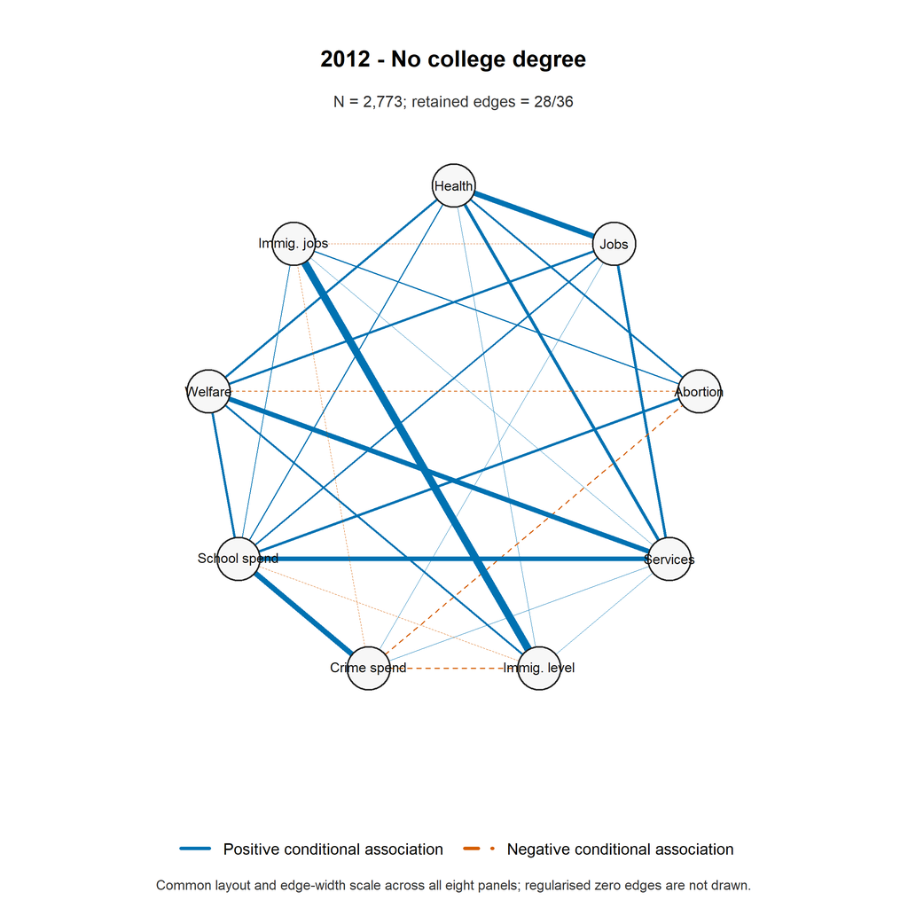

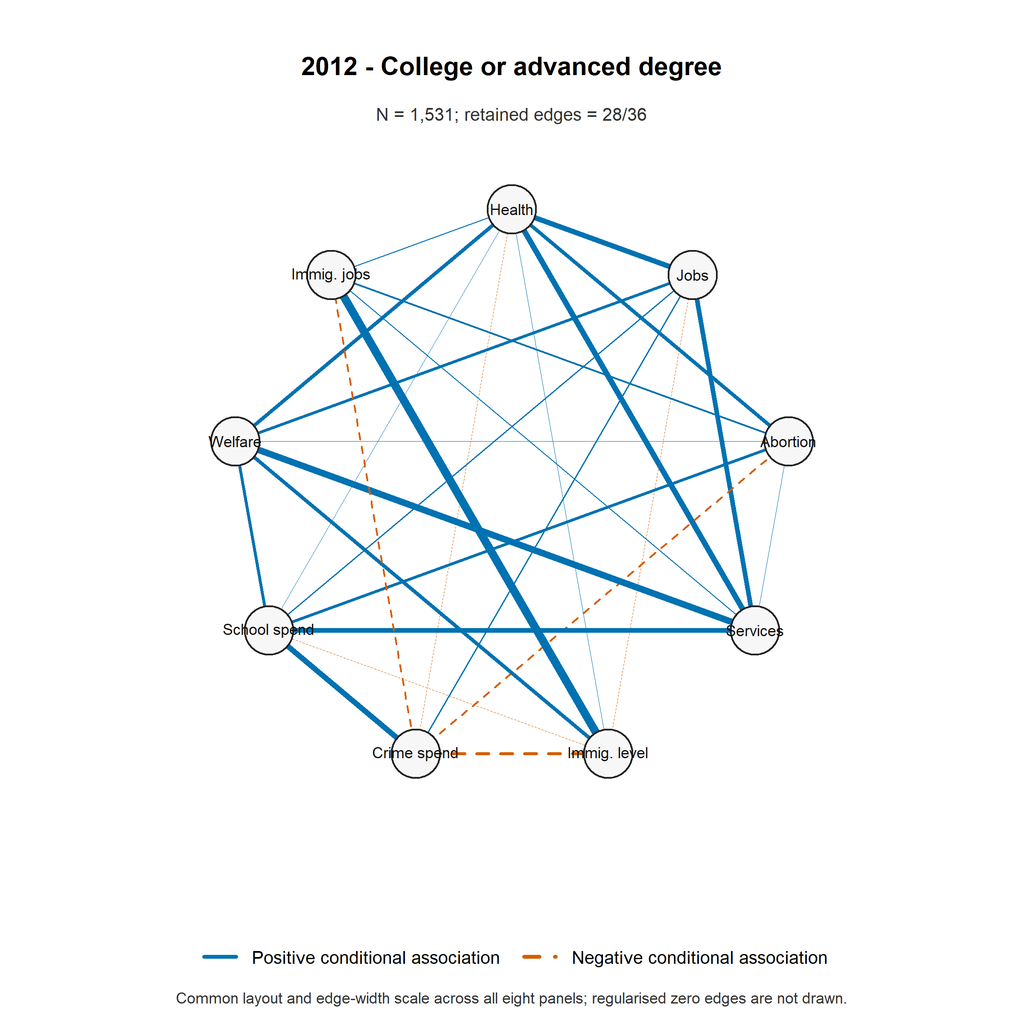

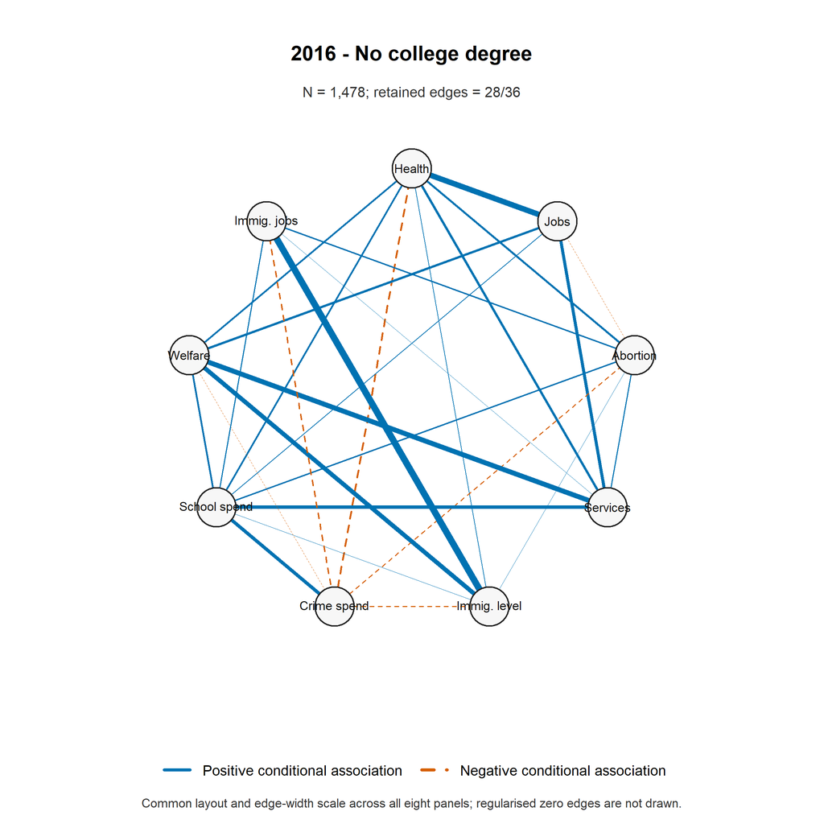

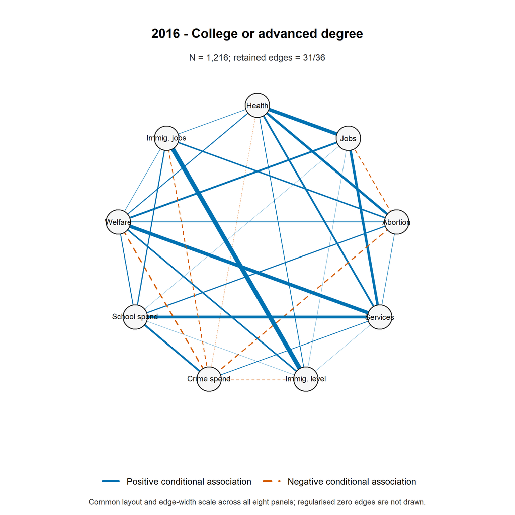

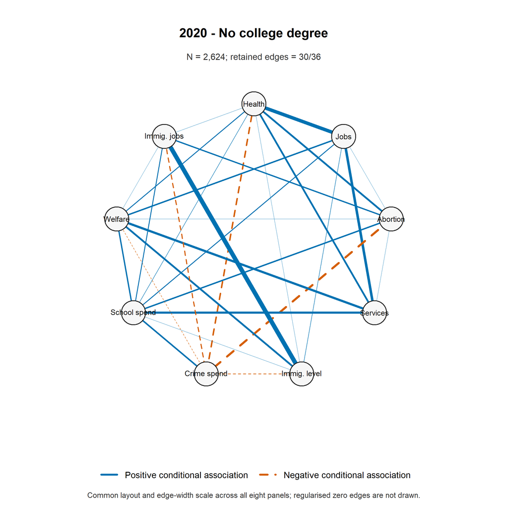

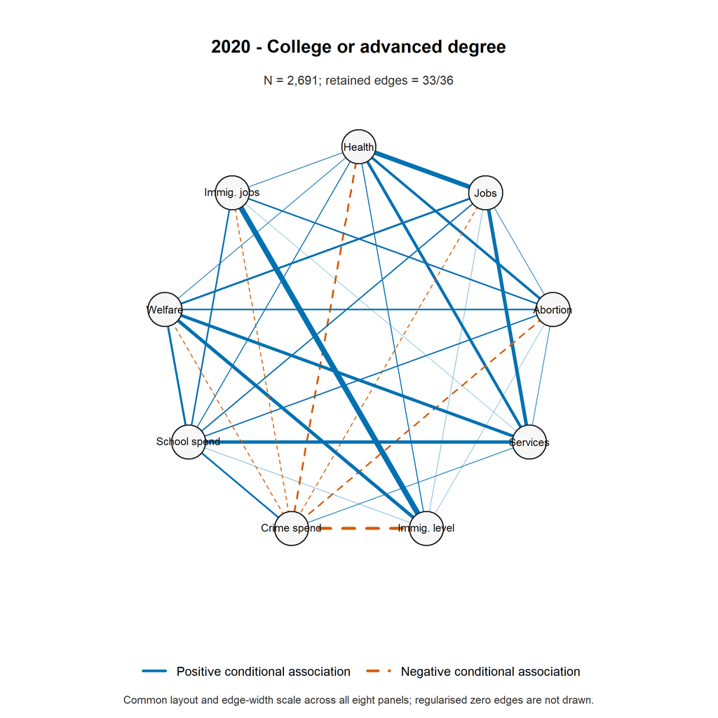

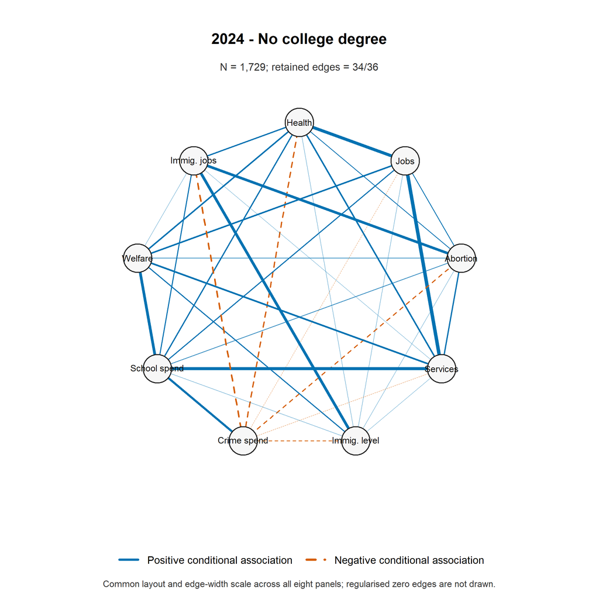

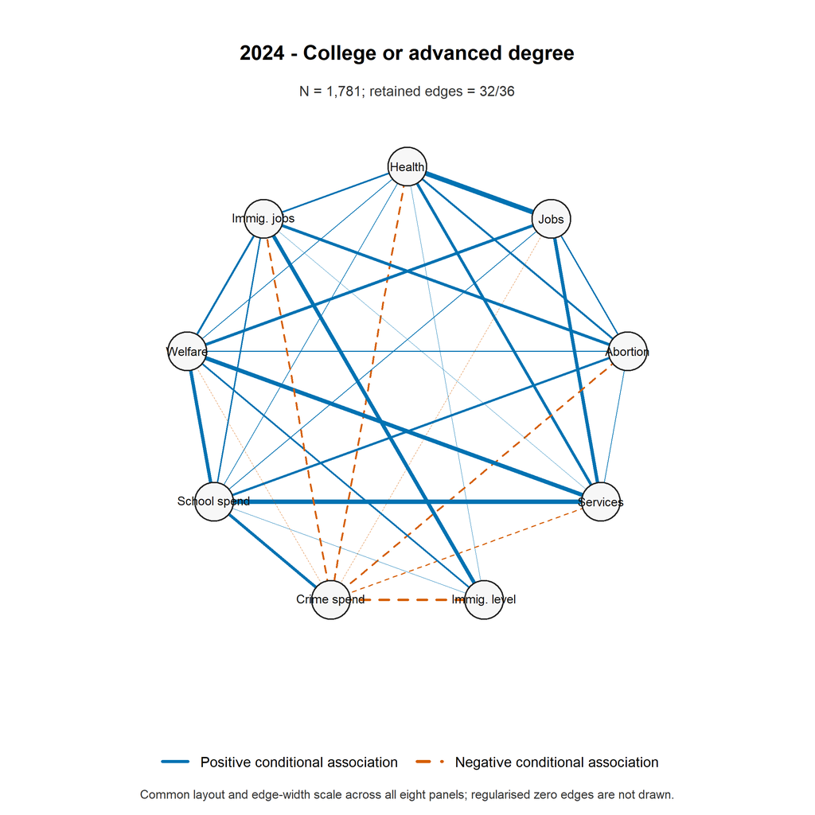

# 15. Education edge-accuracy figures

Every panel uses the same edge order and symmetric horizontal scale. The bars are 95% bootstrap percentile intervals. Visual categories distinguish retained positive edges, retained negative edges and edges not retained under the frozen regularisation procedure. Interval width describes estimation accuracy. Whether an interval includes zero is audit information only and is not a reporting gate, significance test or education-group comparison.

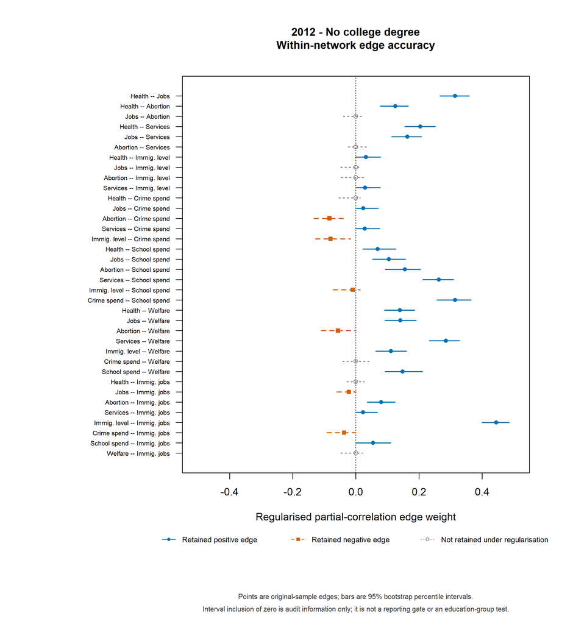

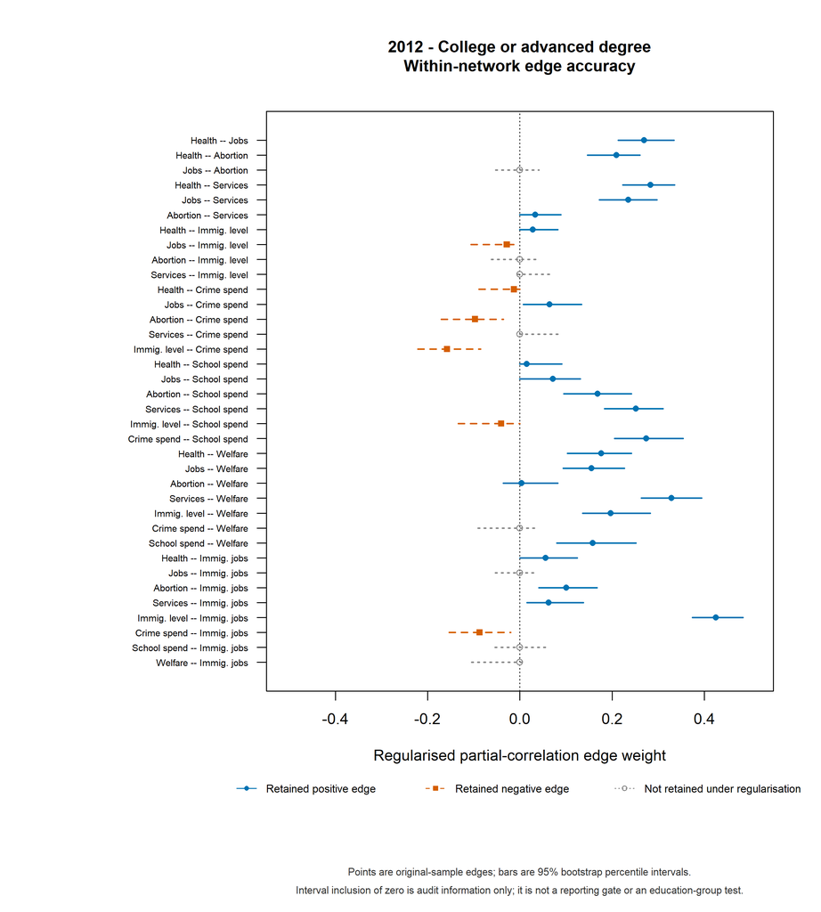

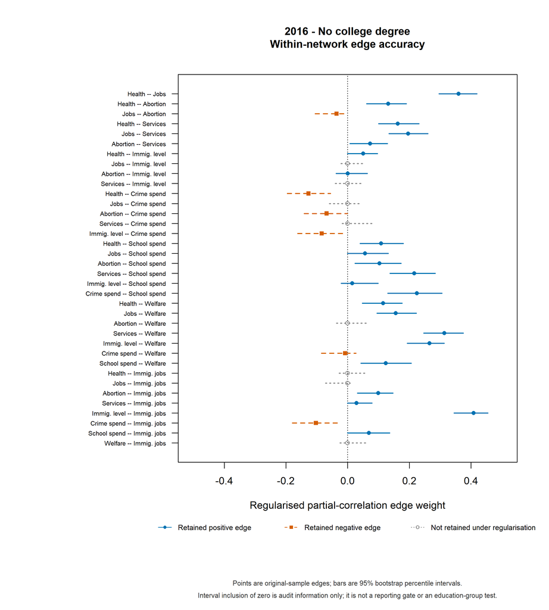

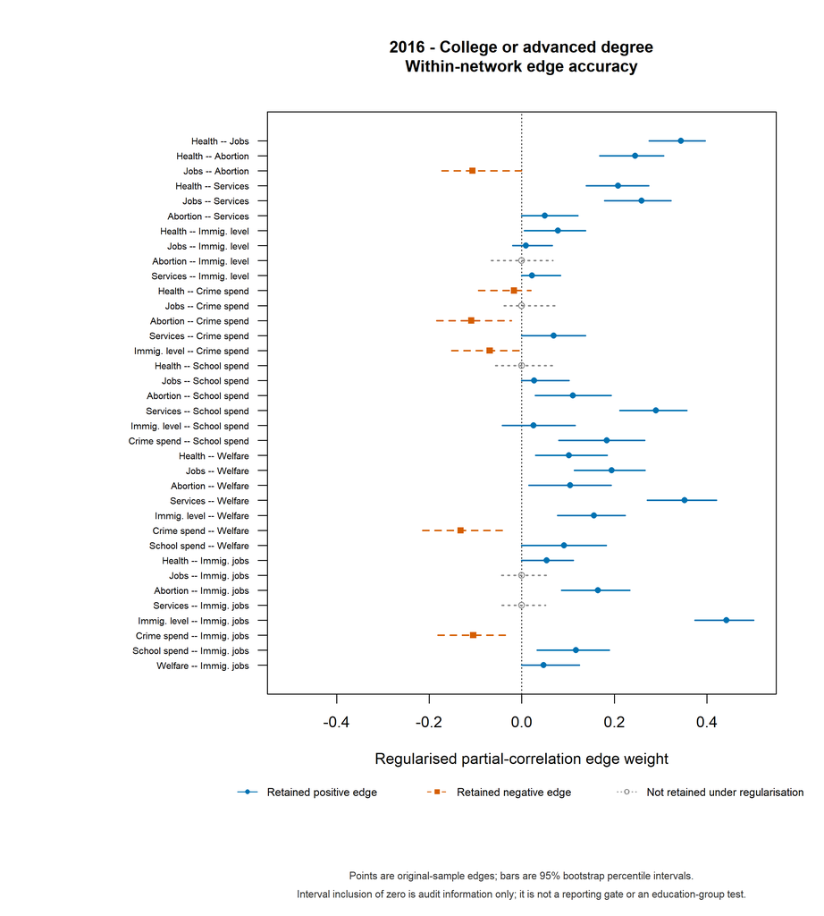

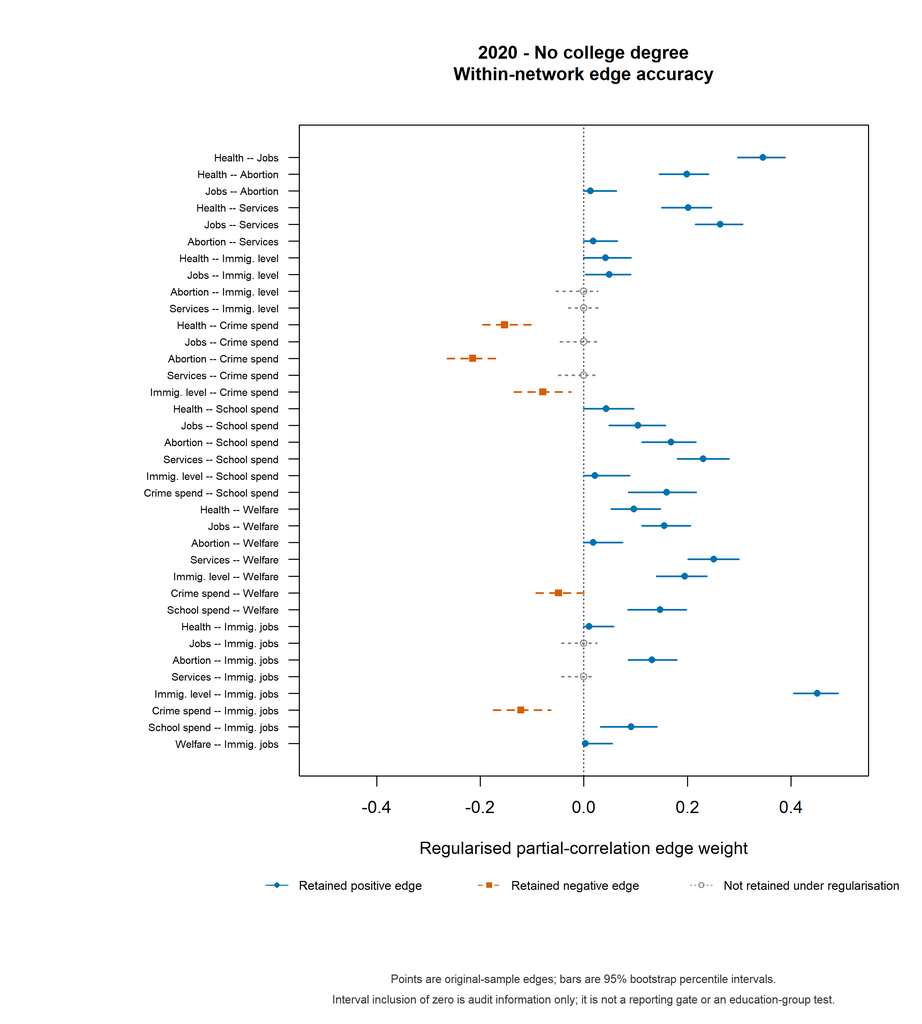

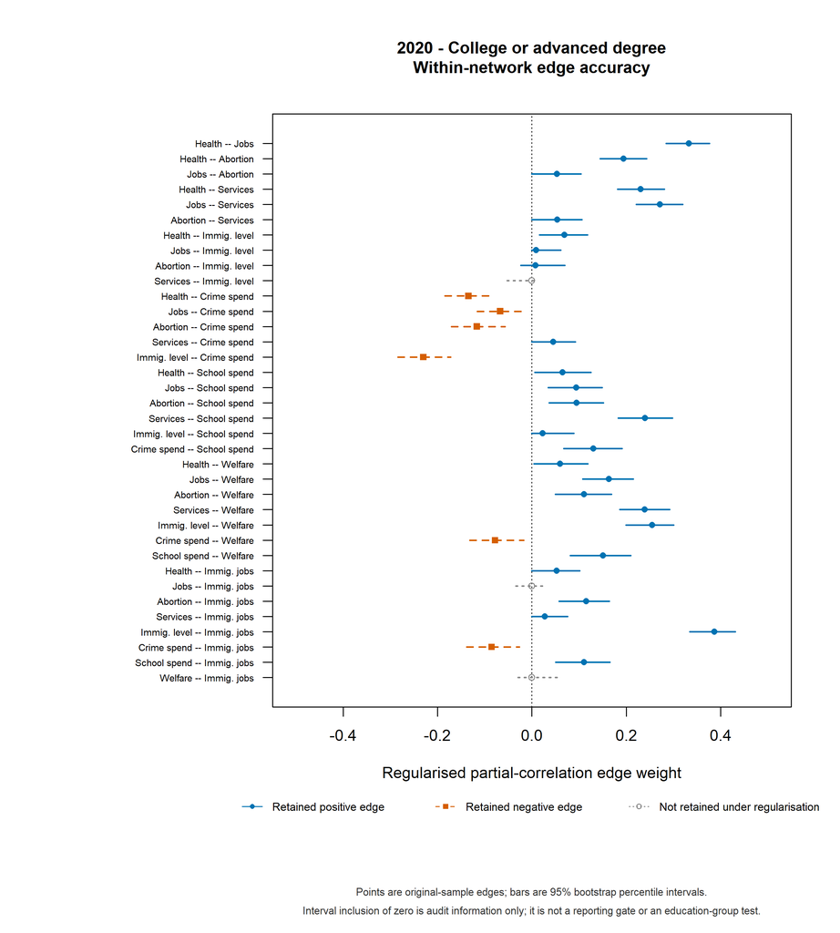

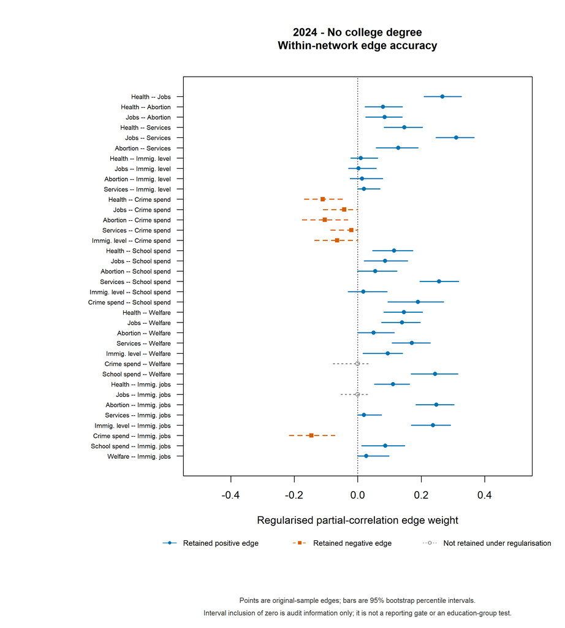

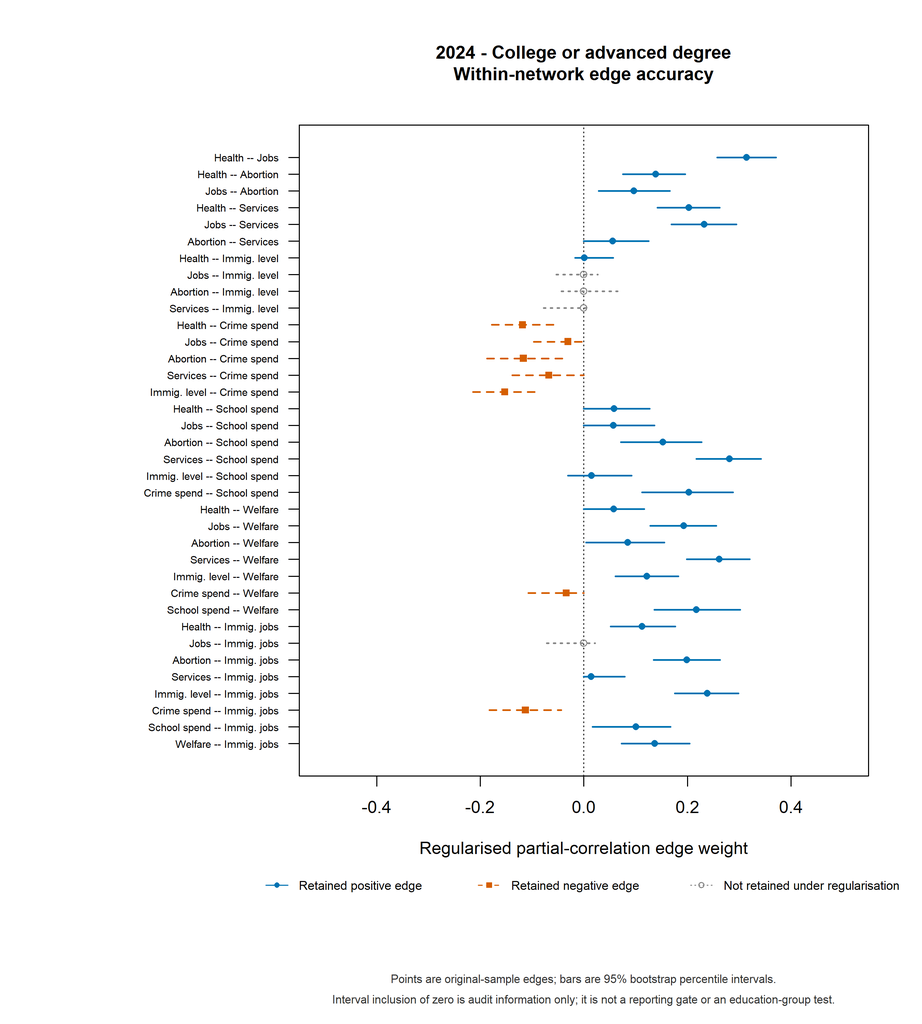

# 16. Log, session information and output inventory

```r
session_file <- file.path(
  log_dir,
  "08C_education_result_readiness_sessionInfo.txt"
)

writeLines(capture.output(sessionInfo()), session_file)

log_file <- file.path(
  log_dir,
  "08C_education_result_readiness.log"
)

writeLines(
  c(
    "STEP 08C EDUCATION RESULT READINESS",
    paste0("Registry: ", normalizePath(registry_path, winslash = "/")),
    paste0("Registry SHA-256: ", file_sha256(registry_path)),
    paste0("Reviewed groups: ", nrow(result_readiness), "/8"),
    paste0("Reviewed edges: ", nrow(edge_accuracy_review), "/288"),
    paste0(
      "Retained edges available for cautious within-network description: ",
      sum(
        edge_accuracy_review$
          Retained_under_EBICglasso
      ),
      "/288"
    ),
    paste0(
      paste(
        "Retained edges with percentile interval",
        "including zero (audit only):"
      ),
      " ",
      sum(
        edge_accuracy_review$
          Retained_under_EBICglasso &
          edge_accuracy_review$
            Percentile_CI_includes_zero
      )
    ),
    paste0("Figures created: ", nrow(figure_manifest), "/16"),
    paste0("Final validation checks passed: ", sum(final_validation$Passed),
      "/", nrow(final_validation)),
    "Network estimation or re-estimation: NOT RUN",
    "Bootstrap execution or re-execution: NOT RUN",
    "Centrality: NOT RUN",
    "NCT: NOT RUN",
    "Formal education-group inference: NOT RUN",
    "Political interpretation: NOT RUN"
  ),
  log_file
)

output_paths <- c(
  edge_accuracy_review_file,
  widest_intervals_file,
  result_readiness_file,
  figure_manifest_file,
  file.path(formal_table_dir, "08C_package_gate.csv"),
  file.path(formal_table_dir, "08C_decision_gate.csv"),
  file.path(formal_table_dir, "08C_source_hash_gate.csv"),
  file.path(formal_table_dir, "08C_input_validation.csv"),
  file.path(formal_table_dir, "08C_prohibited_call_scan.csv"),
  file.path(formal_table_dir, "08C_edge_review_validation.csv"),
  file.path(formal_table_dir, "08C_visual_specification.csv"),
  file.path(formal_table_dir, "08C_final_validation.csv"),
  network_figure_files,
  accuracy_figure_files,
  log_file,
  session_file
)

output_paths <- normalizePath(
  output_paths,
  winslash = "/",
  mustWork = TRUE
)

output_inventory <- data.frame(
  File = basename(output_paths),
  Path = output_paths,
  Bytes = file.info(output_paths)$size,
  SHA256 = vapply(output_paths, file_sha256, FUN.VALUE = character(1)),
  stringsAsFactors = FALSE
)

write.csv(
  output_inventory,
  file.path(formal_table_dir, "08C_output_hash_inventory.csv"),
  row.names = FALSE
)

stopifnot(
  all(output_inventory$Bytes > 0),
  all(nzchar(output_inventory$SHA256))
)

output_inventory
```

```
##                                                                                                                                                                      File
## D:/ANES_code/ANES_dissertation/outputs/tables/formal/08C_education_edge_accuracy_review.csv                                        08C_education_edge_accuracy_review.csv
## D:/ANES_code/ANES_dissertation/outputs/tables/formal/08C_education_widest_intervals.csv                                                08C_education_widest_intervals.csv
## D:/ANES_code/ANES_dissertation/outputs/tables/formal/08C_education_result_readiness.csv                                                08C_education_result_readiness.csv
## D:/ANES_code/ANES_dissertation/outputs/tables/formal/08C_education_figure_manifest.csv                                                  08C_education_figure_manifest.csv
## D:/ANES_code/ANES_dissertation/outputs/tables/formal/08C_package_gate.csv                                                                            08C_package_gate.csv
## D:/ANES_code/ANES_dissertation/outputs/tables/formal/08C_decision_gate.csv                                                                          08C_decision_gate.csv
## D:/ANES_code/ANES_dissertation/outputs/tables/formal/08C_source_hash_gate.csv                                                                    08C_source_hash_gate.csv
## D:/ANES_code/ANES_dissertation/outputs/tables/formal/08C_input_validation.csv                                                                    08C_input_validation.csv
## D:/ANES_code/ANES_dissertation/outputs/tables/formal/08C_prohibited_call_scan.csv                                                            08C_prohibited_call_scan.csv
## D:/ANES_code/ANES_dissertation/outputs/tables/formal/08C_edge_review_validation.csv                                                        08C_edge_review_validation.csv
## D:/ANES_code/ANES_dissertation/outputs/tables/formal/08C_visual_specification.csv                                                            08C_visual_specification.csv
## D:/ANES_code/ANES_dissertation/outputs/tables/formal/08C_final_validation.csv                                                                    08C_final_validation.csv
## D:/ANES_code/ANES_dissertation/outputs/figures/formal/08C_education_network_2012__no_college_degree.png                 08C_education_network_2012__no_college_degree.png
## D:/ANES_code/ANES_dissertation/outputs/figures/formal/08C_education_network_2012__college_or_advanced.png             08C_education_network_2012__college_or_advanced.png
## D:/ANES_code/ANES_dissertation/outputs/figures/formal/08C_education_network_2016__no_college_degree.png                 08C_education_network_2016__no_college_degree.png
## D:/ANES_code/ANES_dissertation/outputs/figures/formal/08C_education_network_2016__college_or_advanced.png             08C_education_network_2016__college_or_advanced.png
## D:/ANES_code/ANES_dissertation/outputs/figures/formal/08C_education_network_2020__no_college_degree.png                 08C_education_network_2020__no_college_degree.png
## D:/ANES_code/ANES_dissertation/outputs/figures/formal/08C_education_network_2020__college_or_advanced.png             08C_education_network_2020__college_or_advanced.png
## D:/ANES_code/ANES_dissertation/outputs/figures/formal/08C_education_network_2024__no_college_degree.png                 08C_education_network_2024__no_college_degree.png
## D:/ANES_code/ANES_dissertation/outputs/figures/formal/08C_education_network_2024__college_or_advanced.png             08C_education_network_2024__college_or_advanced.png
## D:/ANES_code/ANES_dissertation/outputs/figures/formal/08C_education_edge_accuracy_2012__no_college_degree.png     08C_education_edge_accuracy_2012__no_college_degree.png
## D:/ANES_code/ANES_dissertation/outputs/figures/formal/08C_education_edge_accuracy_2012__college_or_advanced.png 08C_education_edge_accuracy_2012__college_or_advanced.png
## D:/ANES_code/ANES_dissertation/outputs/figures/formal/08C_education_edge_accuracy_2016__no_college_degree.png     08C_education_edge_accuracy_2016__no_college_degree.png
## D:/ANES_code/ANES_dissertation/outputs/figures/formal/08C_education_edge_accuracy_2016__college_or_advanced.png 08C_education_edge_accuracy_2016__college_or_advanced.png
## D:/ANES_code/ANES_dissertation/outputs/figures/formal/08C_education_edge_accuracy_2020__no_college_degree.png     08C_education_edge_accuracy_2020__no_college_degree.png
```

[output cut: 98 more lines]

# Final bounded status

The output permits cautious within-network description of edges retained under the frozen EBICglasso procedure when their point estimates, bootstrap intervals and interval widths are reported together. Interval inclusion of zero is retained for audit only and is not a second edge-selection or reporting rule.The output does not establish any statistically significant difference between education groups.